# no lpi models

Ohio bee data # Step 2: Urban Cleveland Pool to Local Greenspaces Comparing among Local habitats # CWM and Functional Diversity - Null Models GLMMs This time without LPI

```r
t <- read.csv("./btraits_final.csv", row.names=1)
a <- read.csv("./bcomm_final.localanalysis.csv", row.names=1)
str(a)
```

```
'data.frame':   49 obs. of  360 variables:
 $ trmt                      : chr  "Farm" "Farm" "Farm" "Control" ...
 $ Agapostemonsericeus       : int  0 0 0 1 1 1 1 0 1 0 ...
 $ Agapostemonsplendens      : int  0 0 0 0 0 0 0 0 0 0 ...
 $ Agapostemontexanus        : int  0 1 1 1 1 1 1 0 1 0 ...
 $ Agapostemonvirescens      : int  1 1 1 1 1 1 1 1 1 1 ...
 $ Andrenaalgida             : int  0 0 0 0 0 0 0 0 0 0 ...
 $ Andrenaaliciae            : int  0 0 0 0 0 0 0 0 0 0 ...
 $ Andrenaalleghaniensis     : int  0 0 0 0 0 0 0 0 0 0 ...
 $ Andrenaandrenoides        : int  0 0 0 0 0 0 0 0 0 0 ...
 $ Andrenaarabis             : int  0 0 0 0 0 0 0 0 0 0 ...
 $ Andrenaasteris            : int  0 0 0 0 0 0 0 0 0 0 ...
 $ Andrenabanksi             : int  0 0 0 0 0 0 0 0 0 0 ...
 $ Andrenabarbara            : int  0 0 0 0 0 0 0 0 0 0 ...
 $ Andrenabarbilabris        : int  0 0 0 1 0 0 0 0 0 0 ...
```

[output cut: 86 more lines]

```r
a1 <- a #save the original dataset

# pull out treatments that we want to keep
farm <- a[which(a$trmt == "Farm"),]
str(farm)
```

```
'data.frame':   8 obs. of  360 variables:
 $ trmt                      : chr  "Farm" "Farm" "Farm" "Farm" ...
 $ Agapostemonsericeus       : int  0 0 0 0 1 0 1 1
 $ Agapostemonsplendens      : int  0 0 0 0 0 0 0 0
 $ Agapostemontexanus        : int  0 1 1 1 1 1 1 1
 $ Agapostemonvirescens      : int  1 1 1 1 1 1 1 1
 $ Andrenaalgida             : int  0 0 0 0 0 0 0 0
 $ Andrenaaliciae            : int  0 0 0 0 0 0 0 0
 $ Andrenaalleghaniensis     : int  0 0 0 0 0 0 0 0
 $ Andrenaandrenoides        : int  0 0 0 0 0 0 0 0
 $ Andrenaarabis             : int  0 0 0 0 0 0 0 0
 $ Andrenaasteris            : int  0 0 0 0 0 0 0 0
 $ Andrenabanksi             : int  0 0 0 0 0 0 0 0
 $ Andrenabarbara            : int  0 0 0 0 0 0 0 0
 $ Andrenabarbilabris        : int  0 0 0 0 0 0 1 0
```

[output cut: 86 more lines]

```r
Control <- a[which(a$trmt == "Control"),]
str(Control)
```

```
'data.frame':   9 obs. of  360 variables:
 $ trmt                      : chr  "Control" "Control" "Control" "Control" ...
 $ Agapostemonsericeus       : int  1 1 1 1 0 1 0 1 0
 $ Agapostemonsplendens      : int  0 0 0 0 0 0 0 0 0
 $ Agapostemontexanus        : int  1 1 1 1 0 1 0 0 1
 $ Agapostemonvirescens      : int  1 1 1 1 1 1 1 1 1
 $ Andrenaalgida             : int  0 0 0 0 0 0 0 0 0
 $ Andrenaaliciae            : int  0 0 0 0 0 0 0 0 0
 $ Andrenaalleghaniensis     : int  0 0 0 0 0 0 0 0 0
 $ Andrenaandrenoides        : int  0 0 0 0 0 0 0 0 0
 $ Andrenaarabis             : int  0 0 0 0 0 0 0 0 0
 $ Andrenaasteris            : int  0 0 0 0 0 0 0 0 0
 $ Andrenabanksi             : int  0 0 0 0 0 0 0 0 0
 $ Andrenabarbara            : int  0 0 0 0 0 0 0 0 0
 $ Andrenabarbilabris        : int  1 0 0 0 0 0 0 0 0
```

[output cut: 34 more lines]

```r
T1 <- a[which(a$trmt == "T1"),]
str(T1)
```

```
'data.frame':   8 obs. of  360 variables:
 $ trmt                      : chr  "T1" "T1" "T1" "T1" ...
 $ Agapostemonsericeus       : int  0 1 0 0 0 0 1 0
 $ Agapostemonsplendens      : int  0 0 0 0 0 0 0 0
 $ Agapostemontexanus        : int  0 0 0 0 0 1 0 1
 $ Agapostemonvirescens      : int  1 1 0 1 1 1 1 1
 $ Andrenaalgida             : int  0 0 0 0 0 0 0 0
 $ Andrenaaliciae            : int  0 0 0 0 0 0 0 0
 $ Andrenaalleghaniensis     : int  0 1 0 0 1 0 0 0
 $ Andrenaandrenoides        : int  0 0 0 0 0 0 0 0
 $ Andrenaarabis             : int  0 0 0 0 0 0 0 0
 $ Andrenaasteris            : int  0 0 0 0 0 0 0 0
 $ Andrenabanksi             : int  0 0 0 0 0 0 0 0
 $ Andrenabarbara            : int  0 0 0 0 0 0 0 0
 $ Andrenabarbilabris        : int  0 0 0 0 0 0 0 0
```

[output cut: 86 more lines]

```r
T8 <- a[which(a$trmt == "T8"),]
str(T8)
```

```
'data.frame':   8 obs. of  360 variables:
 $ trmt                      : chr  "T8" "T8" "T8" "T8" ...
 $ Agapostemonsericeus       : int  0 0 0 1 0 0 0 0
 $ Agapostemonsplendens      : int  0 0 0 0 0 0 0 0
 $ Agapostemontexanus        : int  0 1 0 1 1 1 1 0
 $ Agapostemonvirescens      : int  1 1 1 1 1 1 1 1
 $ Andrenaalgida             : int  0 0 0 0 0 0 0 0
 $ Andrenaaliciae            : int  0 0 0 0 0 0 0 0
 $ Andrenaalleghaniensis     : int  0 0 0 0 0 1 0 0
 $ Andrenaandrenoides        : int  0 0 0 0 0 0 0 0
 $ Andrenaarabis             : int  0 0 0 0 0 0 0 0
 $ Andrenaasteris            : int  0 0 0 0 0 0 0 0
 $ Andrenabanksi             : int  0 0 0 0 0 0 0 0
 $ Andrenabarbara            : int  0 0 0 0 0 0 0 0
 $ Andrenabarbilabris        : int  0 0 0 0 0 0 0 0
```

[output cut: 86 more lines]

```r
# create new dataset with only farm, Control, t1, and t8 treatments
a <- rbind(farm, Control,T1, T8)
str(a)
```

```
'data.frame':   33 obs. of  360 variables:
 $ trmt                      : chr  "Farm" "Farm" "Farm" "Farm" ...
 $ Agapostemonsericeus       : int  0 0 0 0 1 0 1 1 1 1 ...
 $ Agapostemonsplendens      : int  0 0 0 0 0 0 0 0 0 0 ...
 $ Agapostemontexanus        : int  0 1 1 1 1 1 1 1 1 1 ...
 $ Agapostemonvirescens      : int  1 1 1 1 1 1 1 1 1 1 ...
 $ Andrenaalgida             : int  0 0 0 0 0 0 0 0 0 0 ...
 $ Andrenaaliciae            : int  0 0 0 0 0 0 0 0 0 0 ...
 $ Andrenaalleghaniensis     : int  0 0 0 0 0 0 0 0 0 0 ...
 $ Andrenaandrenoides        : int  0 0 0 0 0 0 0 0 0 0 ...
 $ Andrenaarabis             : int  0 0 0 0 0 0 0 0 0 0 ...
 $ Andrenaasteris            : int  0 0 0 0 0 0 0 0 0 0 ...
 $ Andrenabanksi             : int  0 0 0 0 0 0 0 0 0 0 ...
 $ Andrenabarbara            : int  0 0 0 0 0 0 0 0 0 0 ...
 $ Andrenabarbilabris        : int  0 0 0 0 0 0 1 0 1 0 ...
```

[output cut: 86 more lines]

```r
a <- a[2:360]
str(a)
```

```
'data.frame':   33 obs. of  359 variables:
 $ Agapostemonsericeus       : int  0 0 0 0 1 0 1 1 1 1 ...
 $ Agapostemonsplendens      : int  0 0 0 0 0 0 0 0 0 0 ...
 $ Agapostemontexanus        : int  0 1 1 1 1 1 1 1 1 1 ...
 $ Agapostemonvirescens      : int  1 1 1 1 1 1 1 1 1 1 ...
 $ Andrenaalgida             : int  0 0 0 0 0 0 0 0 0 0 ...
 $ Andrenaaliciae            : int  0 0 0 0 0 0 0 0 0 0 ...
 $ Andrenaalleghaniensis     : int  0 0 0 0 0 0 0 0 0 0 ...
 $ Andrenaandrenoides        : int  0 0 0 0 0 0 0 0 0 0 ...
 $ Andrenaarabis             : int  0 0 0 0 0 0 0 0 0 0 ...
 $ Andrenaasteris            : int  0 0 0 0 0 0 0 0 0 0 ...
 $ Andrenabanksi             : int  0 0 0 0 0 0 0 0 0 0 ...
 $ Andrenabarbara            : int  0 0 0 0 0 0 0 0 0 0 ...
 $ Andrenabarbilabris        : int  0 0 0 0 0 0 1 0 1 0 ...
 $ Andrenabisalicis          : int  0 0 0 0 0 0 0 0 0 0 ...
```

[output cut: 86 more lines]

```r
rowSums(a1[2:360])
```

```
 47thStGarden      BluePike       Buckeye
           36            33            29
          C10           C11           C13
           33            36            33
           C5            C6           C69
           50            32            42
           C7            C8            C9
           41            16            43
    Esperanza       Fairfax  LonnieBurten
           28            38            34
      Midtown SlavicVillage           BU1
           46            37            29
          CE1           DS1           FA1
           19            16            24
          GL1           HO1           SV1
           18            21            30
          TR1           BU4           CE4
           31            23            22
          DS4           FA4           GL4
           28            21            37
          HO4           SV4           TR4
           24            29            22
          BU6           CE6           DS6
           27            27            20
          FA6           GL6           HO6
           32            36            28
          SV6           TR6           BU8
           17            36            19
          CE8           DS8           FA8
           23            15            20
          GL8           HO8           SV8
           29            16            27
          TR8
           24
```

```r
# create a vector with the column sums for each species
# species not found in Cleveland will have a 0
sp <- colSums(a)
sp
```

```
       Agapostemonsericeus
                        12
      Agapostemonsplendens
                         0
        Agapostemontexanus
                        20
      Agapostemonvirescens
                        32
             Andrenaalgida
                         0
            Andrenaaliciae
                         0
     Andrenaalleghaniensis
                         3
        Andrenaandrenoides
                         0
             Andrenaarabis
                         0
            Andrenaasteris
                         0
             Andrenabanksi
                         0
            Andrenabarbara
                         0
        Andrenabarbilabris
                         2
          Andrenabisalicis
                         0
           Andrenabradleyi
                         0
        Andrenabrevipalpis
                         0
         Andrenacanadensis
                         0
            Andrenacarlini
                         0
           Andrenacarolina
                         0
           Andrenaceanothi
                         0
```

[output cut: 663 more lines]

```
                         0
         Triepeolusdonatus
                         0
         Triepeoluslunatus
                         2
      Triepeoluspectoralis
                         0
       Triepeolusremigatus
                         1
         Triepeolussimplex
                         0
         Xenoglossastrenua
                         0
         Xylocopavirginica
                        14
```

```r
# removes any columns (i.e. species) that are not found in Cleveland
a <- a[, colSums(a != 0) > 0]
colSums(a)
```

```
     Agapostemonsericeus
                      12
      Agapostemontexanus
                      20
    Agapostemonvirescens
                      32
   Andrenaalleghaniensis
                       3
      Andrenabarbilabris
                       2
          Andrenacommoda
                       9
        Andrenacressonii
                       4
         Andrenadunningi
                       1
        Andrenaerigeniae
                       5
      Andrenamiserabilis
                       3
          Andrenanasonii
                       4
         Andrenaperplexa
                       2
           Andrenavicina
                       1
           Andrenaviolae
                       4
         Andrenawilkella
                      22
           Andrenaziziae
                       1
      Anthidiummanicatum
                       8
     Anthidiumoblongatum
                      14
    Anthophoraterminalis
                       3
           Apismellifera
                      30
```

[output cut: 185 more lines]

```
                       2
      Sphecodescressonii
                       3
   Sphecodesmandibularis
                       7
          Sphecodesminor
                       1
           Stelislouisae
                       1
       Triepeoluslunatus
                       2
     Triepeolusremigatus
                       1
       Xylocopavirginica
                      14
```

```r
str(t)
```

```
'data.frame':   359 obs. of  5 variables:
 $ BodyLength: num  10 10.5 10.2 10.5 8.5 ...
 $ Lecty     : int  1 1 1 1 1 2 1 2 2 2 ...
 $ Nesting   : int  1 1 1 1 1 1 1 1 1 1 ...
 $ Sociality : int  1 1 1 1 2 2 2 2 2 2 ...
 $ Origin    : int  0 0 0 0 0 0 0 0 0 0 ...
```

```r
names(t)
```

```
[1] "BodyLength" "Lecty"      "Nesting"
[4] "Sociality"  "Origin"
```

```r
colnames(t) <- c("bl", "lec", "nest", "soc", "ori")
names(t)
```

```
[1] "bl"   "lec"  "nest" "soc"  "ori"
```

```r
# add the sp vector as a column in the trait matrix, shows which species
# are found in Cleveland and which are absent (i.e. with a 0)
t$sp <- sp
t
```

|  | bl | lec | nest | soc | ori | sp |
| --- | --- | --- | --- | --- | --- | --- |
| Agapostemonsericeus | 10.000 | 1 | 1 | 1 | 0 | 12 |
| Agapostemonsplendens | 10.500 | 1 | 1 | 1 | 0 | 0 |
| Agapostemontexanus | 10.250 | 1 | 1 | 1 | 0 | 20 |
| Agapostemonvirescens | 10.500 | 1 | 1 | 1 | 0 | 32 |
| Andrenaalgida | 8.500 | 1 | 1 | 2 | 0 | 0 |
| Andrenaaliciae | 12.380 | 2 | 1 | 2 | 0 | 0 |
| Andrenaalleghaniensis | 9.250 | 1 | 1 | 2 | 0 | 3 |
| Andrenaandrenoides | 9.250 | 2 | 1 | 2 | 0 | 0 |
| Andrenaarabis | 8.860 | 2 | 1 | 2 | 0 | 0 |
| Andrenaasteris | 11.500 | 2 | 1 | 2 | 0 | 0 |

[output cut: 349 more lines]

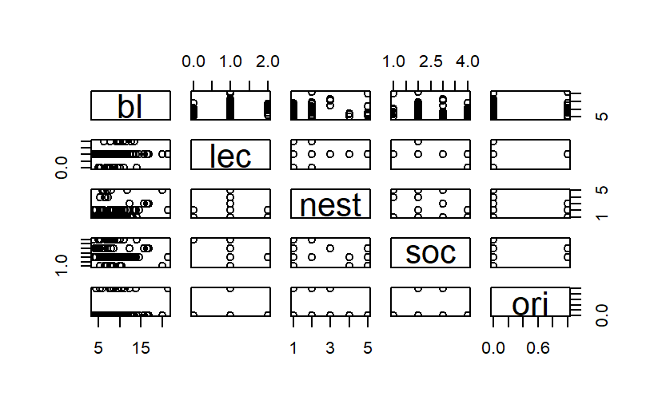

```r
# uses the sp values to remove rows of species not collected in Cleveland
# then remove the column because we don't need it anymore
t <- t[t$sp != 0, ]
t <- t[,-6]

plot(t)
```

```r
cor(t, method = c("pearson"), use = "complete.obs")
```

```
              bl         lec        nest
bl    1.00000000  0.13726775  0.22130115
lec   0.13726775  1.00000000  0.06025784
nest  0.22130115  0.06025784  1.00000000
soc  -0.15597402 -0.61245279 -0.18174737
ori   0.08316398  0.03385873  0.09723153
            soc         ori
bl   -0.1559740  0.08316398
lec  -0.6124528  0.03385873
nest -0.1817474  0.09723153
soc   1.0000000 -0.15993348
ori  -0.1599335  1.00000000
```

```r
str(t)
```

```
'data.frame':   120 obs. of  5 variables:
 $ bl  : num  10 10.25 10.5 9.25 9.75 ...
 $ lec : int  1 1 1 1 1 1 1 1 2 1 ...
 $ nest: int  1 1 1 1 1 1 1 1 1 1 ...
 $ soc : int  1 1 1 2 2 2 2 2 2 2 ...
 $ ori : int  0 0 0 0 0 0 0 0 0 0 ...
```

```r
t1 <- t #save the original dataset

t$lec <- as.factor(t$lec)
t$nest <- as.factor(t$nest)
t$soc <- as.factor(t$soc)

str(t) # have to keep origin as a integer for the trait distance matrix to work
```

```
'data.frame':   120 obs. of  5 variables:
 $ bl  : num  10 10.25 10.5 9.25 9.75 ...
 $ lec : Factor w/ 3 levels "0","1","2": 2 2 2 2 2 2 2 2 3 2 ...
 $ nest: Factor w/ 5 levels "1","2","3","4",..: 1 1 1 1 1 1 1 1 1 1 ...
 $ soc : Factor w/ 4 levels "1","2","3","4": 1 1 1 2 2 2 2 2 2 2 ...
 $ ori : int  0 0 0 0 0 0 0 0 0 0 ...
```

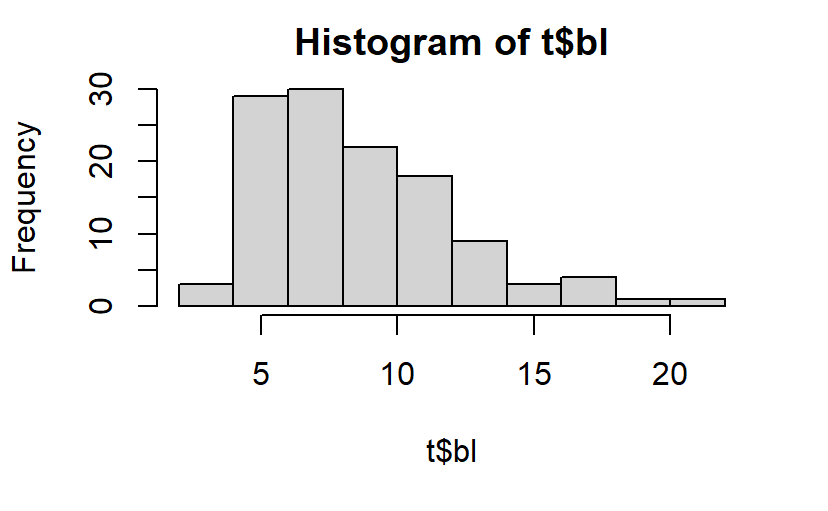

```r
#check body length for normality
hist(t$bl)
```

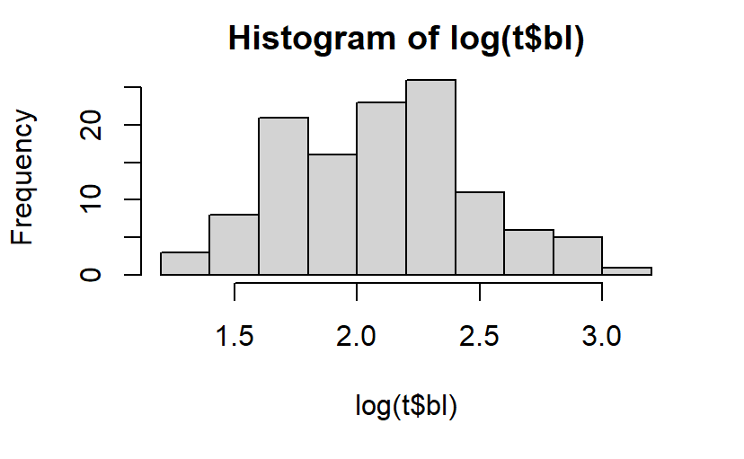

```r
hist(log(t$bl))
```

```r
t2 <- t #create another duplicate dataset before we transform
t2$bl <- log(t2$bl + 1)
str(t2)
```

```
'data.frame':   120 obs. of  5 variables:
 $ bl  : num  2.4 2.42 2.44 2.33 2.37 ...
 $ lec : Factor w/ 3 levels "0","1","2": 2 2 2 2 2 2 2 2 3 2 ...
 $ nest: Factor w/ 5 levels "1","2","3","4",..: 1 1 1 1 1 1 1 1 1 1 ...
 $ soc : Factor w/ 4 levels "1","2","3","4": 1 1 1 2 2 2 2 2 2 2 ...
 $ ori : int  0 0 0 0 0 0 0 0 0 0 ...
```

```r
#Double check that all species are present in both datasets
#Double check if a species is present in one dataset but not the other
setdiff(colnames(a), rownames(t2))
```

```
character(0)
```

```r
setdiff(rownames (t2), colnames(a))
```

```
character(0)
```

```r
rownames(t2) == colnames(a) # we are good to go
```

```
  [1] TRUE TRUE TRUE TRUE TRUE TRUE TRUE TRUE
  [9] TRUE TRUE TRUE TRUE TRUE TRUE TRUE TRUE
 [17] TRUE TRUE TRUE TRUE TRUE TRUE TRUE TRUE
 [25] TRUE TRUE TRUE TRUE TRUE TRUE TRUE TRUE
 [33] TRUE TRUE TRUE TRUE TRUE TRUE TRUE TRUE
 [41] TRUE TRUE TRUE TRUE TRUE TRUE TRUE TRUE
 [49] TRUE TRUE TRUE TRUE TRUE TRUE TRUE TRUE
 [57] TRUE TRUE TRUE TRUE TRUE TRUE TRUE TRUE
 [65] TRUE TRUE TRUE TRUE TRUE TRUE TRUE TRUE
 [73] TRUE TRUE TRUE TRUE TRUE TRUE TRUE TRUE
 [81] TRUE TRUE TRUE TRUE TRUE TRUE TRUE TRUE
 [89] TRUE TRUE TRUE TRUE TRUE TRUE TRUE TRUE
 [97] TRUE TRUE TRUE TRUE TRUE TRUE TRUE TRUE
[105] TRUE TRUE TRUE TRUE TRUE TRUE TRUE TRUE
[113] TRUE TRUE TRUE TRUE TRUE TRUE TRUE TRUE
```

#Observed community metrics Loading needed packages

```r
if (!suppressWarnings(require(FD))) install.packages("FD")
citation("FD")
```

```
please use:

  Laliberté, E., and P. Legendre (2010) A
  distance-based framework for measuring
  functional diversity from multiple
  traits. Ecology 91:299-305.

  Laliberté, E., Legendre, P., and B.
  Shipley. (2014). FD: measuring functional
  diversity from multiple traits, and other
  tools for functional ecology. R package
  version 1.0-12.1.

See http://www.elaliberte.info/publications
for a PDF version of the article.
To see these entries in BibTeX format, use
'print(<citation>, bibtex=TRUE)',
'toBibtex(.)', or set
'options(citation.bibtex.max=999)'.
```

```r
if (!suppressWarnings(require(picante))) install.packages("picante")
citation("picante")
```

```
  S.W. Kembel, P.D. Cowan, M.R. Helmus,
  W.K. Cornwell, H. Morlon, D.D. Ackerly,
  S.P. Blomberg, and C.O. Webb. 2010.
  Picante: R tools for integrating
  phylogenies and ecology. Bioinformatics
  26:1463-1464.

A BibTeX entry for LaTeX users is

  @Article{,
    title = {Picante: {R} tools for integrating phylogenies and ecology},
    author = {S.W. Kembel and P.D. Cowan and M.R. Helmus and W.K. Cornwell and H. Morlon and D.D. Ackerly and S.P. Blomberg and C.O. Webb},
    journal = {Bioinformatics},
    volume = {26},
    pages = {1463--1464},
    year = {2010},
  }
```

```r
if (!suppressWarnings(require(gawdis))) install.packages("gawdis")
```

```
  ____    _
 / ___|  / \     Genetic
| |  _  / _ \    Algorithms
| |_| |/ ___ \
 \____/_/   \_\  version 3.2.2
```

```r
citation("gawdis")
```

```
use:

  de Bello F, Bott-Dukat Z, Leps J, Fibich
  P (2021). _Towards a more balanced
  combination of multiple traits when
  computing functional differences between
  species_. Methods in Ecology and
  Evolution 12: 443-448,
  <https://doi.org/10.1111/2041-210X.13537>.

A BibTeX entry for LaTeX users is

  @Manual{,
    title = {Towards a more balanced combination of multiple traits when computing functional differences between species},
    author = {Francesco {de Bello} and Zoltan Bott-Dukat and Jan Leps and Pavel Fibich},
    year = {2021},
    note = {Methods in Ecology and Evolution 12: 443-448},
    url = {https://doi.org/10.1111/2041-210X.13537},
  }
```

```r
if (!suppressWarnings(require(betapart))) install.packages("betapart")
citation("betapart")
```

```
use:

  Baselga A, Orme D, Villeger S, De Bortoli
  J, Leprieur F, Logez M (2022). _betapart:
  Partitioning Beta Diversity into Turnover
  and Nestedness Components_. R package
  version 1.5.6,
  <https://CRAN.R-project.org/package=betapart>.

A BibTeX entry for LaTeX users is

  @Manual{,
    title = {betapart: Partitioning Beta Diversity into Turnover and Nestedness
Components},
    author = {Andres Baselga and David Orme and Sebastien Villeger and Julien {De Bortoli} and Fabien Leprieur and Maxime Logez},
    year = {2022},
    note = {R package version 1.5.6},
    url = {https://CRAN.R-project.org/package=betapart},
  }
```

```r
rowSums(a)
```

```
 47thStGarden      BluePike       Buckeye
           36            33            29
    Esperanza       Fairfax  LonnieBurten
           28            38            34
      Midtown SlavicVillage           C10
           46            37            33
          C11           C13            C5
           36            33            50
           C6           C69            C7
           32            42            41
           C8            C9           BU1
           16            43            29
          CE1           DS1           FA1
           19            16            24
          GL1           HO1           SV1
           18            21            30
          TR1           BU8           CE8
           31            19            23
          DS8           FA8           GL8
           15            20            29
          HO8           SV8           TR8
           16            27            24
```

```r
#observed CWM
cwm.obs <- functcomp(t2, as.matrix(a), CWM.type = "all")
cwm.obs
```

|  | bl | lec_0 | lec_1 | lec_2 | nest_1 | nest_2 | nest_3 | nest_4 | nest_5 | soc_1 | soc_2 | soc_3 | soc_4 | ori_0 | ori_1 |
| --- | --- | --- | --- | --- | --- | --- | --- | --- | --- | --- | --- | --- | --- | --- | --- |
| 47thStGarden | 2.163205 | 0.13888889 | 0.7222222 | 0.13888889 | 0.7777778 | 0.1388889 | 0.02777778 | 0.02777778 | 0.02777778 | 0.11111111 | 0.4722222 | 0.2500000 | 0.13888889 | 0.9166667 | 0.08333333 |
| BluePike | 2.210897 | 0.00000000 | 0.9090909 | 0.09090909 | 0.6969697 | 0.1515152 | 0.12121212 | 0.03030303 | 0.00000000 | 0.18181818 | 0.3030303 | 0.3939394 | 0.00000000 | 0.8181818 | 0.18181818 |
| Buckeye | 2.141134 | 0.00000000 | 0.9310345 | 0.06896552 | 0.6896552 | 0.1379310 | 0.06896552 | 0.03448276 | 0.06896552 | 0.17241379 | 0.3103448 | 0.4482759 | 0.00000000 | 0.8620690 | 0.13793103 |
| Esperanza | 2.246117 | 0.00000000 | 0.9285714 | 0.07142857 | 0.5714286 | 0.2500000 | 0.10714286 | 0.03571429 | 0.03571429 | 0.17857143 | 0.4285714 | 0.3571429 | 0.00000000 | 0.8214286 | 0.17857143 |
| Fairfax | 2.252568 | 0.05263158 | 0.8947368 | 0.05263158 | 0.6315789 | 0.1578947 | 0.13157895 | 0.02631579 | 0.05263158 | 0.18421053 | 0.3421053 | 0.3157895 | 0.05263158 | 0.8947368 | 0.10526316 |
| LonnieBurten | 2.192812 | 0.08823529 | 0.8529412 | 0.05882353 | 0.6176471 | 0.1764706 | 0.08823529 | 0.05882353 | 0.05882353 | 0.20588235 | 0.2941176 | 0.3235294 | 0.08823529 | 0.8823529 | 0.11764706 |
| Midtown | 2.270164 | 0.02173913 | 0.8913043 | 0.08695652 | 0.5869565 | 0.2391304 | 0.10869565 | 0.02173913 | 0.04347826 | 0.15217391 | 0.4347826 | 0.3260870 | 0.02173913 | 0.8913043 | 0.10869565 |
| SlavicVillage | 2.244907 | 0.05405405 | 0.8648649 | 0.08108108 | 0.5945946 | 0.1891892 | 0.08108108 | 0.05405405 | 0.08108108 | 0.18918919 | 0.4054054 | 0.2972973 | 0.05405405 | 0.8378378 | 0.16216216 |
| C10 | 2.253122 | 0.03030303 | 0.8787879 | 0.09090909 | 0.6363636 | 0.1515152 | 0.12121212 | 0.03030303 | 0.06060606 | 0.21212121 | 0.3939394 | 0.3333333 | 0.03030303 | 0.8484848 | 0.15151515 |
| C11 | 2.261363 | 0.02777778 | 0.9444444 | 0.02777778 | 0.6111111 | 0.1944444 | 0.13888889 | 0.02777778 | 0.02777778 | 0.19444444 | 0.3888889 | 0.3333333 | 0.02777778 | 0.8055556 | 0.19444444 |

[output cut: 23 more lines]

```r
#observed taxonomic beta diversity
# create beta part object for analyses
str(a)
```

```
'data.frame':   33 obs. of  120 variables:
 $ Agapostemonsericeus     : int  0 0 0 0 1 0 1 1 1 1 ...
 $ Agapostemontexanus      : int  0 1 1 1 1 1 1 1 1 1 ...
 $ Agapostemonvirescens    : int  1 1 1 1 1 1 1 1 1 1 ...
 $ Andrenaalleghaniensis   : int  0 0 0 0 0 0 0 0 0 0 ...
 $ Andrenabarbilabris      : int  0 0 0 0 0 0 1 0 1 0 ...
 $ Andrenacommoda          : int  0 0 1 0 1 0 0 0 0 1 ...
 $ Andrenacressonii        : int  0 0 0 0 0 0 1 0 1 1 ...
 $ Andrenadunningi         : int  1 0 0 0 0 0 0 0 0 0 ...
 $ Andrenaerigeniae        : int  1 0 0 0 0 1 1 0 0 0 ...
 $ Andrenamiserabilis      : int  1 0 0 0 0 1 0 0 0 0 ...
 $ Andrenanasonii          : int  1 0 0 0 1 0 0 1 0 0 ...
 $ Andrenaperplexa         : int  0 0 0 0 0 0 0 0 0 0 ...
 $ Andrenavicina           : int  0 0 0 0 0 0 1 0 0 0 ...
 $ Andrenaviolae           : int  0 0 0 0 0 0 0 0 0 0 ...
```

[output cut: 86 more lines]

```r
b.core <- betapart.core(a)

# returns three dissimilarity matrices containing
# pairwise between-site values of each beta-diversity component
b.dist <- beta.pair(b.core, index.family = "sorensen")
str(b.dist)
```

```
List of 3
 $ beta.sim: 'dist' num [1:528] 0.485 0.517 0.357 0.444 0.471 ...
  ..- attr(*, "Labels")= chr [1:33] "47thStGarden" "BluePike" "Buckeye" "Esperanza" ...
  ..- attr(*, "Size")= int 33
  ..- attr(*, "call")= language as.dist.default(m = beta.sim)
  ..- attr(*, "Diag")= logi FALSE
  ..- attr(*, "Upper")= logi FALSE
 $ beta.sne: 'dist' num [1:528] 0.0224 0.052 0.0804 0.015 0.0151 ...
  ..- attr(*, "Labels")= chr [1:33] "47thStGarden" "BluePike" "Buckeye" "Esperanza" ...
  ..- attr(*, "Size")= int 33
  ..- attr(*, "call")= language as.dist.default(m = beta.sne)
  ..- attr(*, "Diag")= logi FALSE
  ..- attr(*, "Upper")= logi FALSE
 $ beta.sor: 'dist' num [1:528] 0.507 0.569 0.438 0.459 0.486 ...
  ..- attr(*, "Labels")= chr [1:33] "47thStGarden" "BluePike" "Buckeye" "Esperanza" ...
  ..- attr(*, "Size")= int 33
  ..- attr(*, "call")= language as.dist.default(m = beta.sor)
  ..- attr(*, "Diag")= logi FALSE
  ..- attr(*, "Upper")= logi FALSE
```

```r
#observed functional beta diversity
#create distance matrix with the traits
#optimized feature helps to weight the traits equally
tdis <- gawdis(t2, w.type = "optimized", opti.maxiter = 500)
```

```
[1] "Running w.type=optimized"
```

#Rao Function

```r
Rao<-function(sample, dfunc, dphyl, weight=F, Jost=F, structure=NULL)   {
  library(ade4)

####function Qdecomp by by VillÃger & Mouillot (J Ecol, 2008) modify by Wilfried Thuiller #####

Qdecomp = function(functdist,abundances, w=TRUE) {

# number and names of local communities
c<-dim(abundances)[1] ; namescomm<-row.names(abundances)
abundances<-as.matrix(abundances)

# if necessary, transformation of functdist into matrix object
if (is.matrix(functdist)==F) functdist<-as.matrix(functdist)

# checking 'abundances' and 'functdist' dimensions
if (dim(functdist)[1]!=dim(functdist)[2])  stop("error : 'functdist' has different number of rows and columns")
if (dim(abundances)[2]!=dim(functdist)[1]) stop("error : different number of species in 'functdist' and 'abundances' ")

# checking NA absence in 'functdist'
if (length(which(is.na(functdist)==T))!=0)  stop("error : NA in 'functdist'")

# replacement of NA by 0 in abundances
if (is.na(sum(abundances))==T)  {
for (i in 1:dim(abundances)[1])
for (j in 1:dim(abundances)[2] )
{ if(is.na(abundances[i,j])==T) abundances[i,j]<- 0 } # end of i j
} # end of if

#  species richness and total abundances in local communities
abloc<-apply(abundances,1,sum)
nbsploc<-apply(abundances,1,function(x) {length(which(x>0))} )

# relative abundances inside each local community
locabrel<-abundances/abloc

# alpha diversity
Qalpha=apply(locabrel, 1, function(x) t(x) %*%  functdist %*% x)

#Wc
Wc = abloc/sum(abloc)

# abundance-weighted mean alpha
mQalpha<-as.numeric(Qalpha%*%abloc/sum(abloc) )

#Villeger's correction
if(w==T) {
    # abundance-weighted mean alpha
    mQalpha<-as.numeric(Qalpha%*%abloc/sum(abloc) )
    totabrel<-apply(abundances,2,sum)/sum(abundances)
    Qalpha = Qalpha*Wc
}

# Rao's original definition: mean of Pi
else {
    mQalpha<-mean(Qalpha)
    totabrel<-apply(locabrel,2,mean)
    }


# gamma diversity
Qgamma<-( totabrel %*% functdist %*% totabrel ) [1]

# beta diversity
Qbeta<-as.numeric( Qgamma-mQalpha )

# standardized beta diversity
Qbetastd<-as.numeric(Qbeta/Qgamma )

# list of results
resQ<-list(Richness_per_plot=nbsploc, Relative_abundance= locabrel, Pi=totabrel, Wc=Wc, Species_abundance_per_plot=abloc, Alpha=Qalpha, Mean_alpha=mQalpha, Gamma=Qgamma, Beta=Qbeta, Standardize_Beta =Qbetastd )

return(resQ)

}


###########function disc originally from S. Pavoine####

disc = function (samples, dis = NULL, structures = NULL, Jost = F)
{
    if (!inherits(samples, "data.frame"))
        stop("Non convenient samples")
    if (any(samples < 0))
        stop("Negative value in samples")
    if (any(apply(samples, 2, sum) < 1e-16))
        stop("Empty samples")
    if (!is.null(dis)) {
        if (!inherits(dis, "dist"))
            stop("Object of class 'dist' expected for distance")
       # if (!is.euclid(dis))
            #stop("Euclidean property is expected for distance")
        dis <- as.matrix(dis)
        if (nrow(samples) != nrow(dis))
            stop("Non convenient samples")
    }
   if (!is.null(structures)) {
        if (!inherits(structures, "data.frame"))
            stop("Non convenient structures")
        m <- match(apply(structures, 2, function(x) length(x)),
            ncol(samples), 0)
        if (length(m[m == 1]) != ncol(structures))
            stop("Non convenient structures")
        m <- match(tapply(1:ncol(structures), as.factor(1:ncol(structures)),
            function(x) is.factor(structures[, x])), TRUE, 0)
        if (length(m[m == 1]) != ncol(structures))
            stop("Non convenient structures")
    }
    Structutil <- function(dp2, Np, unit, Jost) {
        if (!is.null(unit)) {
            modunit <- model.matrix(~-1 + unit)
            sumcol <- apply(Np, 2, sum)
            Ng <- modunit * sumcol
            lesnoms <- levels(unit)
        }
        else {
            Ng <- as.matrix(Np)
            lesnoms <- colnames(Np)
        }
        sumcol <- apply(Ng, 2, sum)
        Lg <- t(t(Ng)/sumcol)
        colnames(Lg) <- lesnoms
        Pg <- as.matrix(apply(Ng, 2, sum)/nbhaplotypes)
        rownames(Pg) <- lesnoms
        deltag <- as.matrix(apply(Lg, 2, function(x) t(x) %*%
            dp2 %*% x))
        ug <- matrix(1, ncol(Lg), 1)
        if(Jost) {
            #dp2 <- as.matrix(as.dist(dfunct01))
            deltag <- as.matrix(apply(Lg, 2, function(x) t(x) %*% dp2 %*% x))
            X=t(Lg) %*% dp2 %*% Lg
            alpha=1/2 * (deltag %*% t(ug) + ug %*% t(deltag))
            Gam = (X + alpha)/2
            alpha = 1/(1-alpha) #Jost correction
            Gam = 1/(1-Gam)  #Jost correction
            Beta_add = Gam - alpha
            Beta_mult = 100*(Gam - alpha)/Gam
        }
        else {
          deltag <- as.matrix(apply(Lg, 2, function(x) t(x) %*% dp2 %*% x))
          X=t(Lg) %*% dp2 %*% Lg
          alpha=1/2 * (deltag %*% t(ug) + ug %*% t(deltag))
          Gam = (X + alpha)/2
          Beta_add = Gam - alpha
          Beta_mult = 100*(Gam - alpha)/Gam
        }
        colnames(Beta_add) <- lesnoms
        rownames(Beta_add) <- lesnoms
        return(list(Beta_add = as.dist(Beta_add), Beta_mult = as.dist(Beta_mult),
          Gamma=as.dist(Gam), Alpha=as.dist(alpha), Ng = Ng, Pg = Pg))
    }
    Diss <- function(dis, nbhaplotypes, samples, structures, Jost) {
        structutil <- list(0)
        structutil[[1]] <- Structutil(dp2 = dis, Np = samples, NULL, Jost)
        diss <- list(structutil[[1]]$Alpha, structutil[[1]]$Gamma, structutil[[1]]$Beta_add, structutil[[1]]$Beta_mult)
         if (!is.null(structures)) {
            for (i in 1:length(structures)) {
                structutil[[i + 1]] <- Structutil(as.matrix(structutil[[1]]$Beta_add),
                  structutil[[1]]$Ng, structures[, i], Jost)
            }
            diss <- c(diss, tapply(1:length(structures), factor(1:length(structures)),
                function(x) as.dist(structutil[[x + 1]]$Beta_add)))
        }
        return(diss)
    }
    nbhaplotypes <- sum(samples)
    diss <- Diss(dis, nbhaplotypes, samples, structures, Jost)
    if (!is.null(structures)) {
        names(diss) <- c("Alpha", "Gamma", "Beta_add", "Beta_prop", "Beta_region")
        return(diss)
    }
    names(diss) <- c("Alpha", "Gamma", "Beta_add", "Beta_prop")
    return(diss)
}






  TD<-FD<-PD<-NULL

 #Taxonomic diversity
  dS <- matrix(1, nrow(sample), nrow(sample)) - diag(rep(1, nrow(sample)))
  temp_qdec<- Qdecomp(dS,t(sample), w=weight)   #Call the Qdecomp function for alpha, gamma and beta estimations.
  TD$Richness_per_plot = temp_qdec$Richness_per_plot
  TD$Relative_abundance = temp_qdec$Relative_abundance
  TD$Pi = temp_qdec$Pi
  TD$Wc = temp_qdec$Wc
  if(Jost){
    TD$Mean_Alpha = 1/(1-temp_qdec$Mean_alpha)
    TD$Alpha = 1/(1-temp_qdec$Alpha)
    TD$Gamma = 1/(1-temp_qdec$Gamma)
    TD$Beta_add = (TD$Gamma -TD$Mean_Alpha )
    TD$Beta_prop = 100*TD$Beta_add/TD$Gamma
    #Call the disc function for alpha, gamma and beta estimations for each pair of samples
    TD$Pairwise_samples<- disc(as.data.frame(sample), as.dist(dS), structure=structure, Jost=Jost)
    }
  else {
    TD$Mean_Alpha = temp_qdec$Mean_alpha
    TD$Alpha = temp_qdec$Alpha
    TD$Gamma = temp_qdec$Gamma
    TD$Beta_add = (TD$Gamma -TD$Mean_Alpha )
    TD$Beta_prop = 100*TD$Beta_add/TD$Gamma
    #Call the disc function for alpha, gamma and beta estimations for each pair of samples
    TD$Pairwise_samples <- disc(as.data.frame(sample), as.dist(dS), structure=structure, Jost=Jost)
  }

  #Functional diversity estimation
  if(!is.null(dfunc)){
    FD<-list()
    if(Jost){
      if(max(dfunc)>1) dfunc <- dfunc/max(dfunc)   #Make sure the distance are between 0 and 1 for the Jost correction
      temp_qdec<- Qdecomp(dfunc,t(sample), w=weight)   #Call the Qdecomp function for alpha, gamma and beta estimations.
       #  FD$Alpha = 1/(1-temp_qdec$Alpha)
         #  FD$Mean_Alpha = mean(FD$Alpha)
        FD$Mean_Alpha = 1/(1-temp_qdec$Mean_alpha)
      FD$Alpha = 1/(1-temp_qdec$Alpha)
      FD$Gamma = 1/(1-temp_qdec$Gamma)
      FD$Beta_add = (FD$Gamma -FD$Mean_Alpha )
      FD$Beta_prop = 100*FD$Beta_add/FD$Gamma
      #Call the disc function for alpha, gamma and beta estimations for each pair of samples
      FD$Pairwise_samples<- disc(as.data.frame(sample), as.dist(dfunc), structure=structure, Jost=Jost)
    }
    else {
      temp_qdec<- Qdecomp(dfunc,t(sample), w=weight) #Call the Qdecomp function for alpha, gamma and beta estimations.
      FD$Mean_Alpha = temp_qdec$Mean_alpha
      FD$Alpha = temp_qdec$Alpha
      FD$Gamma = temp_qdec$Gamma
      FD$Beta_add = (FD$Gamma -FD$Mean_Alpha )
      FD$Beta_prop = 100*FD$Beta_add/FD$Gamma
      #FD$Beta =  temp_qdec$Beta#
      #Call the disc function for alpha, gamma and beta estimations for each pair of samples
      FD$Pairwise_samples <- disc(as.data.frame(sample), as.dist(dfunc), structure=structure, Jost=Jost)
    }
  }
  #Phylogenetic diversity estimation
  if(!is.null(dphyl)){
    PD<-list()
    if(Jost){
      if(max(dphyl)>1) dphyl <- dphyl/max(dphyl)   #Make sure the distance are between 0 and 1 for the Jost correction
      temp_qdec<- Qdecomp(dphyl,t(sample), w=weight)   #Call the Qdecomp function for alpha, gamma and beta estimations.
      PD$Mean_Alpha = 1/(1-temp_qdec$Mean_alpha)
      PD$Alpha = 1/(1-temp_qdec$Alpha)
      PD$Gamma = 1/(1-temp_qdec$Gamma)
      PD$Beta_add = (PD$Gamma -PD$Mean_Alpha )
      PD$Beta_prop = 100*PD$Beta_add/PD$Gamma
      #Call the disc function for alpha, gamma and beta estimations for each pair of samples
      PD$Pairwise_samples<- disc(as.data.frame(sample), as.dist(dphyl), structure=structure, Jost=Jost)
    }
    else {
      temp_qdec<- Qdecomp(dphyl,t(sample), w=weight)  #Call the Qdecomp function for alpha, gamma and beta estimations.
      PD$Mean_Alpha = temp_qdec$Mean_alpha
      PD$Alpha = temp_qdec$Alpha
      PD$Gamma = temp_qdec$Gamma
      PD$Beta_add = (PD$Gamma -PD$Mean_Alpha )
      PD$Beta_prop = 100*PD$Beta_add/PD$Gamma
      #PD$Beta =  temp_qdec$Beta
      #Call the disc function for alpha, gamma and beta estimations for each pair of samples
      PD$Pairwise_samples <- disc(as.data.frame(sample), as.dist(dphyl), structure=structure, Jost=Jost)
    }




  }
  out <- list(TD, FD, PD)
  names(out) <- c("TD", "FD", "PD")
  return(out)

}
```

#observed functional alpha diversity

```r
#observed functional alpha diversity

#run the rao function first!
bb.rao <- Rao(sample = t(a), dfunc = tdis, dphyl = NULL, weight = FALSE, Jost = TRUE, structure = NULL)
falpha <- bb.rao$FD$Alpha
falpha
```

#run the null models with 999 iterations

```r
numberReps <- 999


#create matrices to store the results of each iteration of the null model, for each trait and index:
# for cwms
nbl <- nlec_0 <- nlec_1 <- nlec_2 <- nnest_1 <- nnest_2 <- nnest_3 <- nnest_4 <- nnest_5 <- nsoc_1 <- nsoc_2 <- nsoc_3 <- nsoc_4 <- nori_0 <- nori_1 <- matrix(NA,
                                                                                                                                                               nrow = nrow(a), ncol = numberReps, dimnames = list(rownames(a), paste0("n", 1:numberReps)))

# for taxonomic beta diversity
nbsim <- nbsne <- nbsor <- matrix(NA, nrow = nrow(a), ncol = numberReps,
                                  dimnames = list(rownames(a), paste0("n", 1:numberReps)))

# for functional beta diversity
nfalpha <- nfsim <- nfsne <- nfsor <- matrix(NA, nrow = nrow(a), ncol = numberReps,
                                  dimnames = list(rownames(a), paste0("n", 1:numberReps)))

#create null model for each repetition:

for(i in 1:numberReps){
  print(i)

  # randomized trait matrix
  ntraits <- t2[sample(1:nrow(t2)),]
  rownames(ntraits) <- rownames(t2)

  # randomized presence/absence matrix
  nsp <- randomizeMatrix(samp = a, null.model = "independentswap")

  # randomized trait distance matrix
  ntdis <- gawdis(ntraits, w.type = "user", W = wt)

  # CWM calculations
  cwm.null <- functcomp(x = ntraits, a = as.matrix(nsp), CWM.type = "all")
  nbl[,i] <- cwm.null$bl
  nlec_0[,i] <- cwm.null$lec_0
  nlec_1[,i] <- cwm.null$lec_1
  nlec_2[,i] <- cwm.null$lec_2
  nnest_1[,i] <- cwm.null$nest_1
  nnest_2[,i] <- cwm.null$nest_2
  nnest_3[,i] <- cwm.null$nest_3
  nnest_4[,i] <- cwm.null$nest_4
  nnest_5[,i] <- cwm.null$nest_5
  nsoc_1[,i] <- cwm.null$soc_1
  nsoc_2[,i] <- cwm.null$soc_2
  nsoc_3[,i] <- cwm.null$soc_3
  nsoc_4[,i] <- cwm.null$soc_4
  nori_0[,i] <- cwm.null$ori_0
  nori_1[,i] <- cwm.null$ori_1

  # Functional alpha diversity
  nrao <- Rao(sample = t(nsp), dfunc = ntdis, dphyl = NULL, weight = FALSE, Jost = TRUE, structure = NULL)
  nfalpha[,i] <- nrao$FD$Alpha

  # Taxonomic beta diversity indices
  nb.core <- betapart.core(nsp)
  nb.dist <- beta.pair(nb.core, index.family = "sorensen")
  nsim.dist <- as.matrix(nb.dist$beta.sim)
  nsne.dist <- as.matrix(nb.dist$beta.sne)
  nsor.dist <- as.matrix(nb.dist$beta.sor)
  nbsim[,i] <- colMeans(nsim.dist)
  nbsne[,i] <- colMeans(nsne.dist)
  nbsor[,i] <- colMeans(nsor.dist)

  # Functional beta diversity indices
  npco <- dudi.hillsmith(as.matrix(ntdis), scannf = FALSE, nf = 3)
  nt <- as.matrix(npco$li)
  nb.fun <- functional.beta.pair(nsp, nt, index.family = "sorensen")
  nfsim.dist <- as.matrix(nb.fun$funct.beta.sim)
  nfsne.dist <- as.matrix(nb.fun$funct.beta.sne)
  nfsor.dist <- as.matrix(nb.fun$funct.beta.sor)
  nfsim[,i] <- colMeans(nfsim.dist)
  nfsne[,i] <- colMeans(nfsne.dist)
  nfsor[,i] <- colMeans(nfsor.dist)

}

# save the output matrices
write.csv(nbl, file = "nbl.csv")
write.csv(nlec_0, file = "nlec_0.csv")
write.csv(nlec_1, file = "nlec_1.csv")
write.csv(nlec_2, file = "nlec_2.csv")
write.csv(nnest_1, file = "nnest_1.csv")
write.csv(nnest_2, file = "nnest_2.csv")
write.csv(nnest_3, file = "nnest_3.csv")
write.csv(nnest_4, file = "nnest_4.csv")
write.csv(nnest_5, file = "nnest_5.csv")
write.csv(nsoc_1, file = "nsoc_1.csv")
write.csv(nsoc_2, file = "nsoc_2.csv")
write.csv(nsoc_3, file = "nsoc_3.csv")
write.csv(nsoc_4, file = "nsoc_4.csv")
write.csv(nori_0, file = "nori_0.csv")
write.csv(nori_1, file = "nori_1.csv")

write.csv(nbsim, file = "tbeta_sim.csv")
write.csv(nbsne, file = "tbeta_sne.csv")
write.csv(nbsor, file = "tbeta_sor.csv")

write.csv(nfalpha, file = "falpha.csv")

write.csv(nfsim, file = "fbeta_sim.csv")
write.csv(nfsne, file = "fbeta_sne.csv")
write.csv(nfsor, file = "fbeta_sor.csv")
```

# load the output matrices

```r
nbl <- read.csv("Urban to Local_Null Models_HillSmith_3 Axes/nbl.csv", row.names=1)
nlec_0 <- read.csv("Urban to Local_Null Models_HillSmith_3 Axes/nlec_0.csv", row.names=1)
nlec_1 <- read.csv("Urban to Local_Null Models_HillSmith_3 Axes/nlec_1.csv", row.names=1)
nlec_2 <- read.csv("Urban to Local_Null Models_HillSmith_3 Axes/nlec_2.csv", row.names=1)
nnest_1 <- read.csv("Urban to Local_Null Models_HillSmith_3 Axes/nnest_1.csv", row.names=1)
nnest_2 <- read.csv("Urban to Local_Null Models_HillSmith_3 Axes/nnest_2.csv", row.names=1)
nnest_3 <- read.csv("Urban to Local_Null Models_HillSmith_3 Axes/nnest_3.csv", row.names=1)
nnest_4 <- read.csv("Urban to Local_Null Models_HillSmith_3 Axes/nnest_4.csv", row.names=1)
nnest_5 <- read.csv("Urban to Local_Null Models_HillSmith_3 Axes/nnest_5.csv", row.names=1)
nsoc_1 <- read.csv("Urban to Local_Null Models_HillSmith_3 Axes/nsoc_1.csv", row.names=1)
nsoc_2 <- read.csv("Urban to Local_Null Models_HillSmith_3 Axes/nsoc_2.csv", row.names=1)
nsoc_3 <- read.csv("Urban to Local_Null Models_HillSmith_3 Axes/nsoc_3.csv", row.names=1)
nsoc_4 <- read.csv("Urban to Local_Null Models_HillSmith_3 Axes/nsoc_4.csv", row.names=1)
nori_0 <- read.csv("Urban to Local_Null Models_HillSmith_3 Axes/nori_0.csv", row.names=1)
nori_1 <- read.csv("Urban to Local_Null Models_HillSmith_3 Axes/nori_1.csv", row.names=1)

nfalpha <- read.csv("Urban to Local_Null Models_HillSmith_3 Axes/falpha.csv", row.names=1)

nbsim <- read.csv("Urban to Local_Null Models_HillSmith_3 Axes/tbeta_sim.csv", row.names=1)
nbsne <- read.csv("Urban to Local_Null Models_HillSmith_3 Axes/tbeta_sne.csv", row.names=1)
nbsor <- read.csv("Urban to Local_Null Models_HillSmith_3 Axes/tbeta_sim.csv", row.names=1)

nfsim <- read.csv("Urban to Local_Null Models_HillSmith_3 Axes/fbeta_sim.csv", row.names=1)
nfsne <- read.csv("Urban to Local_Null Models_HillSmith_3 Axes/fbeta_sne.csv", row.names=1)
nfsor <- read.csv("Urban to Local_Null Models_HillSmith_3 Axes/fbeta_sor.csv", row.names=1)
```

# SES Calculations

```r
## body length
SES_bl <- (cwm.obs$bl - apply(nbl, MARGIN = 1, mean)) / apply(nbl, MARGIN = 1, sd, na.rm=T)
SES_bl

## lec_0 - Kleptoparasitic
SES_lec_0 <- (cwm.obs$lec_0 - apply(nlec_0, MARGIN = 1, mean)) / apply(nlec_0, MARGIN = 1, sd, na.rm=T)
SES_lec_0

## lec_1 - Generalist
SES_lec_1 <- (cwm.obs$lec_1 - apply(nlec_1, MARGIN = 1, mean)) / apply(nlec_1, MARGIN = 1, sd, na.rm=T)
SES_lec_1

## lec_2 - Specialist
SES_lec_2 <- (cwm.obs$lec_2 - apply(nlec_2, MARGIN = 1, mean)) / apply(nlec_2, MARGIN = 1, sd, na.rm=T)
SES_lec_2

## nest_1 - Soil
SES_nest_1 <- (cwm.obs$nest_1 - apply(nnest_1, MARGIN = 1, mean)) / apply(nnest_1, MARGIN = 1, sd, na.rm=T)
SES_nest_1

## nest_2 - Cavity
SES_nest_2 <- (cwm.obs$nest_2 - apply(nnest_2, MARGIN = 1, mean)) / apply(nnest_2, MARGIN = 1, sd, na.rm=T)
SES_nest_2

## nest_3 - Hive
SES_nest_3 <- (cwm.obs$nest_3 - apply(nnest_3, MARGIN = 1, mean)) / apply(nnest_3, MARGIN = 1, sd, na.rm=T)
SES_nest_3

## nest_4 - Pithy Stems
SES_nest_4 <- (cwm.obs$nest_4 - apply(nnest_4, MARGIN = 1, mean)) / apply(nnest_4, MARGIN = 1, sd, na.rm=T)
SES_nest_4

## nest_5 - Wood
SES_nest_5 <- (cwm.obs$nest_5 - apply(nnest_5, MARGIN = 1, mean)) / apply(nnest_5, MARGIN = 1, sd, na.rm=T)
SES_nest_5

## soc_1 - Subsocial
SES_soc_1 <- (cwm.obs$soc_1 - apply(nsoc_1, MARGIN = 1, mean)) / apply(nsoc_1, MARGIN = 1, sd, na.rm=T)
SES_soc_1

## soc_2 - Solitary
SES_soc_2 <- (cwm.obs$soc_2 - apply(nsoc_2, MARGIN = 1, mean)) / apply(nsoc_2, MARGIN = 1, sd, na.rm=T)
SES_soc_2

## soc_3 - Eusocial
SES_soc_3 <- (cwm.obs$soc_3 - apply(nsoc_3, MARGIN = 1, mean)) / apply(nsoc_3, MARGIN = 1, sd, na.rm=T)
SES_soc_3

## soc_4 - Parasitic
SES_soc_4 <- (cwm.obs$soc_4 - apply(nsoc_4, MARGIN = 1, mean)) / apply(nsoc_4, MARGIN = 1, sd, na.rm=T)
SES_soc_4

## ori_0 - Native
SES_ori_0 <- (cwm.obs$ori_0 - apply(nori_0, MARGIN = 1, mean)) / apply(nori_0, MARGIN = 1, sd, na.rm=T)
SES_ori_0

## ori_2 - Exotic
SES_ori_1 <- (cwm.obs$ori_1 - apply(nori_1, MARGIN = 1, mean)) / apply(nori_1, MARGIN = 1, sd, na.rm=T)
SES_ori_1

## taxonomic beta diversity----
beta.sor <- as.matrix(b.dist$beta.sor)
beta.sor <- colMeans(beta.sor)

beta.sim <- as.matrix(b.dist$beta.sim)
beta.sim <- colMeans(beta.sim)

beta.sne <- as.matrix(b.dist$beta.sne)
beta.sne <- colMeans(beta.sne)

beta.t <- data.frame(beta.sor, beta.sim, beta.sne)

## taxonomic diveristy - beta sor
SES_bsor <- (beta.t$beta.sor - apply(nbsor, MARGIN = 1, mean)) / apply(nbsor, MARGIN = 1, sd, na.rm=T)
SES_bsor

## taxonomic diveristy - beta sim
SES_bsim <- (beta.t$beta.sim - apply(nbsim, MARGIN = 1, mean)) / apply(nbsim, MARGIN = 1, sd, na.rm=T)
SES_bsim

## taxonomic diveristy - beta sne
SES_bsne <- (beta.t$beta.sne - apply(nbsne, MARGIN = 1, mean)) / apply(nbsne, MARGIN = 1, sd, na.rm=T)
SES_bsne

## functional diversity----
fbeta.sor <- as.matrix(b.fun$funct.beta.sor)
fbeta.sor <- colMeans(fbeta.sor)

fbeta.sim <- as.matrix(b.fun$funct.beta.sim)
fbeta.sim <- colMeans(fbeta.sim)

fbeta.sne <- as.matrix(b.fun$funct.beta.sne)
fbeta.sne <- colMeans(fbeta.sne)

beta.f <- data.frame(falpha, fbeta.sor, fbeta.sim, fbeta.sne)

## functional alpha  - Rao
SES_falpha <- (beta.f$falpha - apply(nfalpha, MARGIN = 1, mean)) / apply(nfalpha, MARGIN = 1, sd, na.rm=T)
SES_falpha

## functional diveristy - beta sor
SES_fbsor <- (beta.f$fbeta.sor - apply(nfsor, MARGIN = 1, mean)) / apply(nfsor, MARGIN = 1, sd, na.rm=T)
SES_fbsor

## functional diveristy - beta sim
SES_fbsim <- (beta.f$fbeta.sim - apply(nfsim, MARGIN = 1, mean)) / apply(nfsim, MARGIN = 1, sd, na.rm=T)
SES_fbsim

## functional diveristy - beta sne
SES_fbsne <- (beta.f$fbeta.sne - apply(nfsne, MARGIN = 1, mean)) / apply(nfsne, MARGIN = 1, sd, na.rm=T)
SES_fbsne

## combine all indices into one matrix
SES.all <- as.data.frame(cbind(SES_bl, SES_lec_0, SES_lec_1, SES_lec_2, SES_ori_0, SES_ori_1,
                           SES_nest_1, SES_nest_2, SES_nest_3, SES_nest_4, SES_nest_5,
                           SES_soc_1, SES_soc_2, SES_soc_3, SES_soc_4, SES_bsor, SES_bsim,
                           SES_bsne, SES_falpha, SES_fbsor, SES_fbsim, SES_fbsne))

write.csv(SES.all, file = "SES_Local.csv")
#import the SES data
SES.all <- read.csv("./SES_Local.csv", row.names = 1)
```

# import the landscape data

```r
land <- read.csv("./landscape.localanalysis.csv", row.names = 1)
str(land)

land$trmt <- as.factor(land$trmt)
str(land)

## merge landscape data with SES data
SES <- merge(SES.all, land, by = c("row.names"))
str(SES)

SES$site <- as.factor(SES$Row.names)
str(SES)

write.csv(SES, file = "SES.csv")
## pull out data for each treatment
farm <- SES[which(SES$trmt == "Farm"),]
str(farm)

control <- SES[which(SES$trmt == "Control"),]
str(control)

T1 <- SES[which(SES$trmt == "T1"),]
str(T1)

T8 <- SES[which(SES$trmt == "T8"),]
str(T8)
```

#Loading More packages

```r
if (!suppressWarnings(require(nortest))) install.packages("nortest")
citation("nortest")
```

```
use:

  Gross J, Ligges U (2015). _nortest:
  Tests for Normality_. R package version
  1.0-4,
  <https://CRAN.R-project.org/package=nortest>.

A BibTeX entry for LaTeX users is

  @Manual{,
    title = {nortest: Tests for Normality},
    author = {Juergen Gross and Uwe Ligges},
    year = {2015},
    note = {R package version 1.0-4},
    url = {https://CRAN.R-project.org/package=nortest},
  }
```

```r
if (!suppressWarnings(require(car))) install.packages("car")
citation("car")
```

```
use:

  John Fox and Sanford Weisberg (2019). An
  {R} Companion to Applied Regression,
  Third Edition. Thousand Oaks CA: Sage.
  URL:
  https://socialsciences.mcmaster.ca/jfox/Books/Companion/

A BibTeX entry for LaTeX users is

  @Book{,
    title = {An {R} Companion to Applied Regression},
    edition = {Third},
    author = {John Fox and Sanford Weisberg},
    year = {2019},
    publisher = {Sage},
    address = {Thousand Oaks {CA}},
    url = {https://socialsciences.mcmaster.ca/jfox/Books/Companion/},
  }
```

```r
if (!suppressWarnings(require(emmeans))) install.packages("emmeans")
citation("emmeans")
```

```
use:

  Lenth R (2022). _emmeans: Estimated
  Marginal Means, aka Least-Squares
  Means_. R package version 1.8.0,
  <https://CRAN.R-project.org/package=emmeans>.

A BibTeX entry for LaTeX users is

  @Manual{,
    title = {emmeans: Estimated Marginal Means, aka Least-Squares Means},
    author = {Russell V. Lenth},
    year = {2022},
    note = {R package version 1.8.0},
    url = {https://CRAN.R-project.org/package=emmeans},
  }
```

```r
if (!suppressWarnings(require(bbmle))) install.packages("bbmle")
citation("bbmle")
```

```
use:

  Bolker B, R Development Core Team
  (2022). _bbmle: Tools for General
  Maximum Likelihood Estimation_. R
  package version 1.0.25,
  <https://CRAN.R-project.org/package=bbmle>.

A BibTeX entry for LaTeX users is

  @Manual{,
    title = {bbmle: Tools for General Maximum Likelihood Estimation},
    author = {Ben Bolker and {R Development Core Team}},
    year = {2022},
    note = {R package version 1.0.25},
    url = {https://CRAN.R-project.org/package=bbmle},
  }
```

```r
if (!suppressWarnings(require(DHARMa))) install.packages("DHARMa")
citation("DHARMa")
```

```
use:

  Hartig F (2022). _DHARMa: Residual
  Diagnostics for Hierarchical
  (Multi-Level / Mixed) Regression
  Models_. R package version 0.4.5,
  <https://CRAN.R-project.org/package=DHARMa>.

A BibTeX entry for LaTeX users is

  @Manual{,
    title = {DHARMa: Residual Diagnostics for Hierarchical (Multi-Level / Mixed)
Regression Models},
    author = {Florian Hartig},
    year = {2022},
    note = {R package version 0.4.5},
    url = {https://CRAN.R-project.org/package=DHARMa},
  }
```

```r
if (!suppressWarnings(require(lme4))) install.packages("lme4")
citation("lme4")
```

```
  Douglas Bates, Martin Maechler, Ben
  Bolker, Steve Walker (2015). Fitting
  Linear Mixed-Effects Models Using lme4.
  Journal of Statistical Software, 67(1),
  1-48. doi:10.18637/jss.v067.i01.

A BibTeX entry for LaTeX users is

  @Article{,
    title = {Fitting Linear Mixed-Effects Models Using {lme4}},
    author = {Douglas Bates and Martin M{\"a}chler and Ben Bolker and Steve Walker},
    journal = {Journal of Statistical Software},
    year = {2015},
    volume = {67},
    number = {1},
    pages = {1--48},
    doi = {10.18637/jss.v067.i01},
  }
```

```r
if (!suppressWarnings(require(ggplot2))) install.packages("ggplot2")
citation("ggplot2")
```

```
use:

  H. Wickham. ggplot2: Elegant Graphics
  for Data Analysis. Springer-Verlag New
  York, 2016.

A BibTeX entry for LaTeX users is

  @Book{,
    author = {Hadley Wickham},
    title = {ggplot2: Elegant Graphics for Data Analysis},
    publisher = {Springer-Verlag New York},
    year = {2016},
    isbn = {978-3-319-24277-4},
    url = {https://ggplot2.tidyverse.org},
  }
```

```r
if (!suppressWarnings(require(sjPlot))) install.packages("sjPlot")
citation("sjPlot")
```

```
use:

  Lüdecke D (2022). _sjPlot: Data
  Visualization for Statistics in Social
  Science_. R package version 2.8.11,
  <https://CRAN.R-project.org/package=sjPlot>.

A BibTeX entry for LaTeX users is

  @Manual{,
    title = {sjPlot: Data Visualization for Statistics in Social Science},
    author = {Daniel Lüdecke},
    year = {2022},
    note = {R package version 2.8.11},
    url = {https://CRAN.R-project.org/package=sjPlot},
  }
```

```r
if (!suppressWarnings(require(jtools))) install.packages("jtools")
citation("jtools")
```

```
use:

  Long JA (2022). _jtools: Analysis and
  Presentation of Social Scientific Data_.
  R package version 2.2.0,
  <https://cran.r-project.org/package=jtools>.

A BibTeX entry for LaTeX users is

  @Manual{jtools,
    title = {jtools: Analysis and Presentation of Social Scientific Data},
    author = {Jacob A. Long},
    year = {2022},
    note = {R package version 2.2.0},
    url = {https://cran.r-project.org/package=jtools},
  }
```

```r
if (!suppressWarnings(require(interactions))) install.packages("interactions")
citation("interactions")
```

```
publications use:

  Long JA (2019). _interactions:
  Comprehensive, User-Friendly Toolkit for
  Probing Interactions_. R package version
  1.1.0,
  <https://cran.r-project.org/package=interactions>.

A BibTeX entry for LaTeX users is

  @Manual{interactions,
    title = {interactions: Comprehensive, User-Friendly Toolkit for Probing Interactions},
    author = {Jacob A. Long},
    year = {2019},
    note = {R package version 1.1.0},
    url = {https://cran.r-project.org/package=interactions},
  }
```

```r
check relationships among landscape variables----
dotchart(land$pland, pch = 19)
dotchart(land$lpi, pch = 19)
dotchart(land$enn, pch = 19)
plot(land[2:4], pch = 19)
cor(land[2:4], method = c("pearson"), use = "complete.obs")
```

#Creating FS Matrix

```r
f.farm <- SES[which(SES$trmt == "Farm"),]
str(f.farm)
```

```
'data.frame':   8 obs. of  28 variables:
 $ Row.names : 'AsIs' chr  "47thStGarden" "BluePike" "Buckeye" "Esperanza" ...
 $ SES_bl    : num  -1.101 -0.128 -1.326 0.526 0.81 ...
 $ SES_lec_0 : num  0.101 -2.587 -2.379 -2.36 -1.78 ...
 $ SES_lec_1 : num  -0.927 2.142 2.202 2.17 2.055 ...
 $ SES_lec_2 : num  1.19484 0.00431 -0.43363 -0.40318 -0.93782 ...
 $ SES_ori_0 : num  0.728 -1.276 -0.406 -1.072 0.274 ...
 $ SES_ori_1 : num  -0.728 1.276 0.406 1.072 -0.274 ...
 $ SES_nest_1: num  2.724 1.535 1.217 -0.198 0.651 ...
 $ SES_nest_2: num  -2.036 -1.829 -1.787 -0.287 -1.839 ...
 $ SES_nest_3: num  -0.933 1.842 0.298 1.315 2.351 ...
 $ SES_nest_4: num  -0.194 -0.0827 0.08 0.1381 -0.3101 ...
 $ SES_nest_5: num  -0.728 -1.5716 0.4707 -0.402 0.0126 ...
 $ SES_soc_1 : num  0.342 1.853 1.494 1.659 2.045 ...
 $ SES_soc_2 : num  -0.0694 -2.3551 -1.994 -0.5615 -1.9226 ...
 $ SES_soc_3 : num  0.436 2.765 3.223 1.933 1.633 ...
 $ SES_soc_4 : num  -0.242 -2.738 -2.494 -2.565 -2.014 ...
 $ SES_bsor  : num  5.69 3.41 3.39 1.53 2.51 ...
 $ SES_bsim  : num  2.982 0.802 1.186 -0.996 -1.118 ...
 $ SES_bsne  : num  -3.055 -0.745 -1.005 1.257 0.903 ...
 $ SES_falpha: num  -1.103 -0.997 -1.749 -0.736 -0.933 ...
 $ SES_fbsor : num  4.76 4.87 3.62 3.65 3.83 ...
 $ SES_fbsim : num  2.945 3.829 1.573 1.769 0.419 ...
 $ SES_fbsne : num  2.97 2.98 3.76 3.53 3.67 ...
 $ trmt      : Factor w/ 4 levels "Control","Farm",..: 2 2 2 2 2 2 2 2
 $ pland     : num  36 35.8 45.4 38.2 43.9 ...
 $ lpi       : num  1.06 1.1 2.54 1.48 3.22 3.22 0.5 2.31
 $ enn       : num  6.13 5.87 5.64 6.23 7.22 ...
 $ site      : Factor w/ 33 levels "47thStGarden",..: 1 2 5 19 22 27 28 29
```

```r
f.control <- SES[which(SES$trmt == "Control"),]
str(f.control)
```

```
'data.frame':   9 obs. of  28 variables:
 $ Row.names : 'AsIs' chr  "C10" "C11" "C13" "C5" ...
 $ SES_bl    : num  0.799 0.965 1.135 -1.809 -0.999 ...
 $ SES_lec_0 : num  -2.018 -2.239 -0.817 -2.507 -1.345 ...
 $ SES_lec_1 : num  1.63 2.86 1.13 2.64 2.11 ...
 $ SES_lec_2 : num  0.015 -1.584 -0.699 -0.934 -1.368 ...
 $ SES_ori_0 : num  -0.688 -1.726 -0.666 -0.633 -1.387 ...
 $ SES_ori_1 : num  0.688 1.726 0.666 0.633 1.387 ...
 $ SES_nest_1: num  0.5857 0.3226 -0.1762 0.1402 0.0333 ...
 $ SES_nest_2: num  -1.753 -1.242 -0.866 -0.559 -0.268 ...
 $ SES_nest_3: num  1.849 2.596 1.821 0.115 -0.762 ...
 $ SES_nest_4: num  -0.0675 -0.1984 -0.0916 0.3623 -0.0258 ...
 $ SES_nest_5: num  0.376 -0.748 0.3 0.406 1.288 ...
 $ SES_soc_1 : num  2.542 2.261 2.563 1.897 0.569 ...
 $ SES_soc_2 : num  -1.076 -1.249 -1.112 -1.001 -0.928 ...
 $ SES_soc_3 : num  1.78 2.02 0.25 1.19 2.42 ...
 $ SES_soc_4 : num  -2.25 -2.44 -1.09 -2.37 -1.57 ...
 $ SES_bsor  : num  3.16 2.27 2.18 6.4 4.24 ...
 $ SES_bsim  : num  0.56 -1.28 -0.62 -0.81 1.78 ...
 $ SES_bsne  : num  -0.751 0.979 0.586 0.581 -1.714 ...
 $ SES_falpha: num  -0.132 -0.478 0.199 -1.687 -1.003 ...
 $ SES_fbsor : num  4.11 4.01 4.67 3.46 3.26 ...
 $ SES_fbsim : num  2.262 1.092 3.033 0.241 -0.647 ...
 $ SES_fbsne : num  3.17 3.49 3.1 2.95 4.83 ...
 $ trmt      : Factor w/ 4 levels "Control","Farm",..: 1 1 1 1 1 1 1 1 1
 $ pland     : num  41.7 46.2 47.9 39 49.3 ...
 $ lpi       : num  1.1 1.16 1.23 2.36 1.65 1.94 1.65 1.5 1.5
 $ enn       : num  5.92 5.46 6.02 5.46 4.92 ...
 $ site      : Factor w/ 33 levels "47thStGarden",..: 6 7 8 9 10 11 12 13 14
```

```r
FS_comps <- as.data.frame(rbind(f.control, f.farm))
```

```r
str(k.t1)
```

```
'data.frame':   8 obs. of  28 variables:
 $ Row.names : 'AsIs' chr  "BU1" "CE1" "DS1" "FA1" ...
 $ SES_bl    : num  2.471 -0.2902 1.1226 -0.0674 -0.4407 ...
 $ SES_lec_0 : num  -2.3 -1.87 -1.69 -2.16 -1.03 ...
 $ SES_lec_1 : num  3.14 2.5 2.28 2.84 1.75 ...
 $ SES_lec_2 : num  -1.93 -1.39 -1.33 -1.71 -1.39 ...
 $ SES_ori_0 : num  -2.3203 -2.0318 -0.0946 -3.5483 -1.4982 ...
 $ SES_ori_1 : num  2.3203 2.0318 0.0946 3.5483 1.4982 ...
 $ SES_nest_1: num  -3.517 0.412 -0.294 -2.904 0.186 ...
 $ SES_nest_2: num  1.0306 -0.0708 -1.332 1.2818 0.1252 ...
 $ SES_nest_3: num  3.93 1.01 3.57 3.6 -1.13 ...
 $ SES_nest_4: num  1.254 -0.843 -0.773 0.324 -0.861 ...
 $ SES_nest_5: num  0.474 -1.117 0.225 -0.25 1.23 ...
 $ SES_soc_1 : num  1.543 0.911 -0.517 1.229 0.192 ...
 $ SES_soc_2 : num  0.078283 0.000987 -1.358188 -0.179538 0.725612 ...
 $ SES_soc_3 : num  0.707 1.649 2.702 1.919 -0.611 ...
 $ SES_soc_4 : num  -2.52 -1.98 -1.81 -2.31 -1.2 ...
 $ SES_bsor  : num  2.76 2.85 3.4 2.41 5.15 ...
 $ SES_bsim  : num  0.421 -0.173 -0.486 -0.005 2.305 ...
 $ SES_bsne  : num  -0.0349 0.0904 0.6985 -0.2717 -2.1886 ...
 $ SES_falpha: num  -0.414 -1.034 -1.039 0.691 -0.866 ...
 $ SES_fbsor : num  4.79 2.21 3.85 5.53 1.39 ...
 $ SES_fbsim : num  0.3987 0.0205 0.7333 2.6616 1.7673 ...
 $ SES_fbsne : num  6.225 2.171 3.424 5.028 0.679 ...
 $ trmt      : Factor w/ 4 levels "Control","Farm",..: 3 3 3 3 3 3 3 3
 $ pland     : num  50.8 26.3 40.7 41.3 46.4 ...
 $ lpi       : num  1.65 0.63 1.42 1.71 1.24 0.58 2.29 1.81
 $ enn       : num  5.14 7.52 4.76 7.19 5.55 ...
 $ site      : Factor w/ 33 levels "47thStGarden",..: 3 15 17 20 23 25 30 32
```

#Creating VL Matrix

```r
VL_comps <- as.data.frame(rbind(f.control, k.t1))#here you bind by rows rather than columns (like the code above)
```

#Body Length Models Normality et al testing

```r
with(FS_comps, bartlett.test(SES_bl ~ trmt))
```

```
    Bartlett test of homogeneity of variances

data:  SES_bl by trmt
Bartlett's K-squared = 0.14042, df = 1,
p-value = 0.7079
```

```r
with(KT_comps, bartlett.test(SES_bl ~ trmt))
```

```
    Bartlett test of homogeneity of variances

data:  SES_bl by trmt
Bartlett's K-squared = 0.16803, df = 1,
p-value = 0.6819
```

```r
with(VL_comps, bartlett.test(SES_bl ~ trmt))
```

```
    Bartlett test of homogeneity of variances

data:  SES_bl by trmt
Bartlett's K-squared = 0.06213, df = 1,
p-value = 0.8032
```

```r
with(FS_comps, ad.test(SES_bl))
```

```
    Anderson-Darling normality test

data:  SES_bl
A = 0.46198, p-value = 0.2259
```

```r
with(KT_comps, ad.test(SES_bl))
```

```
    Anderson-Darling normality test

data:  SES_bl
A = 0.29492, p-value = 0.5524
```

```r
with(VL_comps, ad.test(SES_bl))
```

```
    Anderson-Darling normality test

data:  SES_bl
A = 0.38983, p-value = 0.3433
```

```r
#Full model
FS_bl.mod.full <- glm(SES_bl ~ trmt + pland + enn, family = gaussian, data = FS_comps)
summary(FS_bl.mod.full)
```

```
Call:
glm(formula = SES_bl ~ trmt + pland + enn, family = gaussian,
    data = FS_comps)

Deviance Residuals:
    Min       1Q   Median       3Q      Max
-1.2361  -0.6559  -0.3139   0.7128   1.1928

Coefficients:
             Estimate Std. Error t value
(Intercept) -10.55259    4.18267  -2.523
trmtFarm     -0.12201    0.61927  -0.197
pland         0.10097    0.05922   1.705
enn           1.06398    0.43807   2.429
            Pr(>|t|)
(Intercept)   0.0255 *
trmtFarm      0.8469
pland         0.1120
enn           0.0304 *
---
Signif. codes:
0 ‘***’ 0.001 ‘**’ 0.01 ‘*’ 0.05 ‘.’ 0.1 ‘ ’ 1

(Dispersion parameter for gaussian family taken to be 0.8246936)

    Null deviance: 16.411  on 16  degrees of freedom
Residual deviance: 10.721  on 13  degrees of freedom
AIC: 50.407

Number of Fisher Scoring iterations: 2
```

```r
step(FS_bl.mod.full)
```

```
Start:  AIC=50.41
SES_bl ~ trmt + pland + enn

        Df Deviance    AIC
- trmt   1   10.753 48.457
<none>       10.721 50.407
- pland  1   13.118 51.838
- enn    1   15.586 54.767

Step:  AIC=48.46
SES_bl ~ pland + enn

        Df Deviance    AIC
<none>       10.753 48.457
- pland  1   14.017 50.963
- enn    1   16.098 53.318

Call:  glm(formula = SES_bl ~ pland + enn, family = gaussian, data = FS_comps)

Coefficients:
(Intercept)        pland          enn
   -10.6300       0.1061       1.0311

Degrees of Freedom: 16 Total (i.e. Null);  14 Residual
Null Deviance:      16.41
Residual Deviance: 10.75    AIC: 48.46
```

###Reduced model

```r
FS_bl.mod.red <- glm(SES_bl ~ pland + enn, family = gaussian, data = FS_comps)
summary(FS_bl.mod.red)
```

```
Call:
glm(formula = SES_bl ~ pland + enn, family = gaussian, data = FS_comps)

Deviance Residuals:
    Min       1Q   Median       3Q      Max
-1.3262  -0.6609  -0.3286   0.6793   1.1458

Coefficients:
             Estimate Std. Error t value
(Intercept) -10.62997    4.01869  -2.645
pland         0.10606    0.05145   2.061
enn           1.03108    0.39084   2.638
            Pr(>|t|)
(Intercept)   0.0192 *
pland         0.0584 .
enn           0.0195 *
---
Signif. codes:
0 ‘***’ 0.001 ‘**’ 0.01 ‘*’ 0.05 ‘.’ 0.1 ‘ ’ 1

(Dispersion parameter for gaussian family taken to be 0.7680734)

    Null deviance: 16.411  on 16  degrees of freedom
Residual deviance: 10.753  on 14  degrees of freedom
AIC: 48.457

Number of Fisher Scoring iterations: 2
```

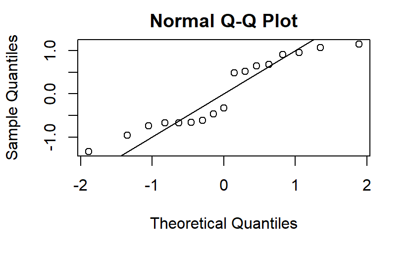

```r
qqnorm(resid(FS_bl.mod.red))
qqline(resid(FS_bl.mod.red))
```

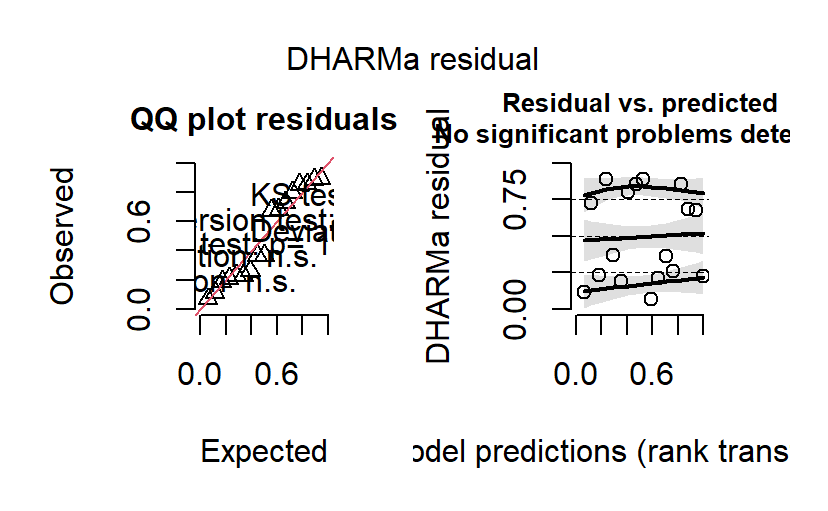

```r
plot(simulateResiduals(FS_bl.mod.red))
```

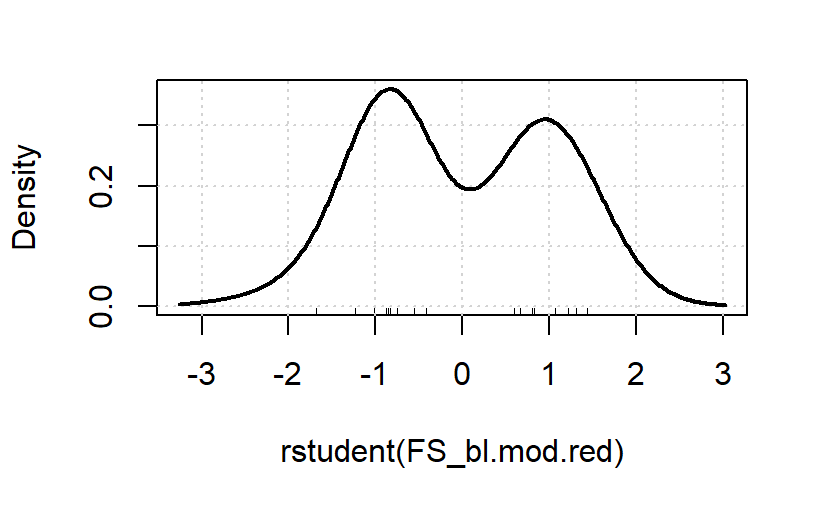

```r
densityPlot(rstudent(FS_bl.mod.red)) # check density estimate of the distribution of residuals
```

```r
outlierTest(FS_bl.mod.red)
```

```
No Studentized residuals with Bonferroni p < 0.05
Largest |rstudent|:
```

|  | rstudent | unadjusted p-value | Bonferroni p |
| --- | --- | --- | --- |
| 5 | -1.677205 | 0.093502 | NA |

[figure not shown]

```r
influenceIndexPlot(FS_bl.mod.red, vars = c("Cook"), id = list(n = 3))
```

```r
#It doesn't look like there really is an outlier with Bonferroini
```

```r
FS_bl.mod.null <- glm(SES_bl ~ 1, family = gaussian, data = FS_comps)

# model comparison techniques
anova(FS_bl.mod.full, FS_bl.mod.red, FS_bl.mod.null, test = "F")
```

```
Analysis of Deviance Table

Model 1: SES_bl ~ trmt + pland + enn
Model 2: SES_bl ~ pland + enn
Model 3: SES_bl ~ 1
  Resid. Df Resid. Dev Df Deviance      F
1        13     10.721
2        14     10.753 -1  -0.0320 0.0388
3        16     16.411 -2  -5.6582 3.4305
   Pr(>F)
1
2 0.84686
3 0.06363 .
---
Signif. codes:
0 ‘***’ 0.001 ‘**’ 0.01 ‘*’ 0.05 ‘.’ 0.1 ‘ ’ 1
```

```r
AICctab(FS_bl.mod.full, FS_bl.mod.red, FS_bl.mod.null)
```

```
               dAICc df
FS_bl.mod.red  0.0   4
FS_bl.mod.null 0.7   2
FS_bl.mod.full 4.1   5
```

###Creating Graphs and Table data

```r
Anova(FS_bl.mod.red)
```

```
Analysis of Deviance Table (Type II tests)

Response: SES_bl
      LR Chisq Df Pr(>Chisq)
pland   4.2490  1   0.039273 *
enn     6.9594  1   0.008338 **
---
Signif. codes:
0 ‘***’ 0.001 ‘**’ 0.01 ‘*’ 0.05 ‘.’ 0.1 ‘ ’ 1
```

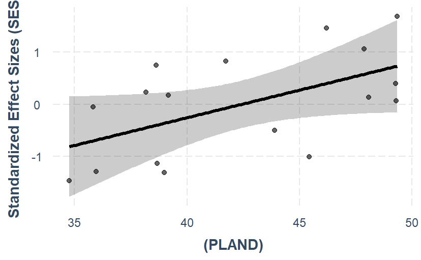

```r
effect_plot(FS_bl.mod.red, pred = pland, interval = TRUE, partial.residuals = TRUE, x.label = '(PLAND)', y.label = 'Standardized Effect Sizes (SES)')
```

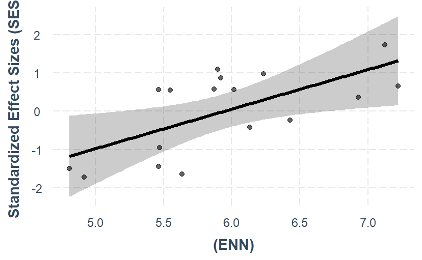

```r
effect_plot(FS_bl.mod.red, pred = enn, interval = TRUE, partial.residuals = TRUE, x.label = '(ENN)', y.label = 'Standardized Effect Sizes (SES)')
```

###Katie’s BL models

```r
KT_bl.mod.full <- glm(SES_bl ~ trmt + pland + enn, family = gaussian, data = KT_comps)
summary(KT_bl.mod.full)
```

```
Call:
glm(formula = SES_bl ~ trmt + pland + enn, family = gaussian,
    data = KT_comps)

Deviance Residuals:
    Min       1Q   Median       3Q      Max
-2.3700  -0.6580  -0.1514   0.7358   2.1037

Coefficients:
             Estimate Std. Error t value
(Intercept)  0.906759   4.838518   0.187
trmtT8       0.488065   0.595371   0.820
pland       -0.005169   0.058175  -0.089
enn         -0.053866   0.449722  -0.120
            Pr(>|t|)
(Intercept)    0.854
trmtT8         0.428
pland          0.931
enn            0.907

(Dispersion parameter for gaussian family taken to be 1.416213)

    Null deviance: 17.974  on 15  degrees of freedom
Residual deviance: 16.995  on 12  degrees of freedom
AIC: 56.371

Number of Fisher Scoring iterations: 2
```

```r
step(KT_bl.mod.full)
```

```
Start:  AIC=56.37
SES_bl ~ trmt + pland + enn

        Df Deviance    AIC
- pland  1   17.006 54.381
- enn    1   17.015 54.390
- trmt   1   17.946 55.243
<none>       16.995 56.371

Step:  AIC=54.38
SES_bl ~ trmt + enn

       Df Deviance    AIC
- enn   1   17.015 52.390
- trmt  1   17.957 53.252
<none>      17.006 54.381

Step:  AIC=52.39
SES_bl ~ trmt

       Df Deviance    AIC
- trmt  1   17.974 51.267
<none>      17.015 52.390

Step:  AIC=51.27
SES_bl ~ 1


Call:  glm(formula = SES_bl ~ 1, family = gaussian, data = KT_comps)

Coefficients:
(Intercept)
     0.6037

Degrees of Freedom: 15 Total (i.e. Null);  15 Residual
Null Deviance:      17.97
Residual Deviance: 17.97    AIC: 51.27
```

```r
KT_bl.mod.null <- glm(SES_bl ~ 1, family = gaussian, data = KT_comps)
summary(KT_bl.mod.null)
```

```
Call:
glm(formula = SES_bl ~ 1, family = gaussian, data = KT_comps)

Deviance Residuals:
    Min       1Q   Median       3Q      Max
-2.1022  -0.8201  -0.1738   0.9930   1.8673

Coefficients:
            Estimate Std. Error t value Pr(>|t|)
(Intercept)   0.6037     0.2737   2.206   0.0434

(Intercept) *
---
Signif. codes:
0 ‘***’ 0.001 ‘**’ 0.01 ‘*’ 0.05 ‘.’ 0.1 ‘ ’ 1

(Dispersion parameter for gaussian family taken to be 1.198249)

    Null deviance: 17.974  on 15  degrees of freedom
Residual deviance: 17.974  on 15  degrees of freedom
AIC: 51.267

Number of Fisher Scoring iterations: 2
```

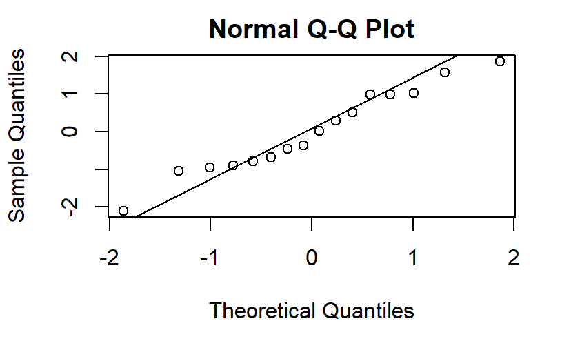

```r
qqnorm(resid(KT_bl.mod.null))
qqline(resid(KT_bl.mod.null))
```

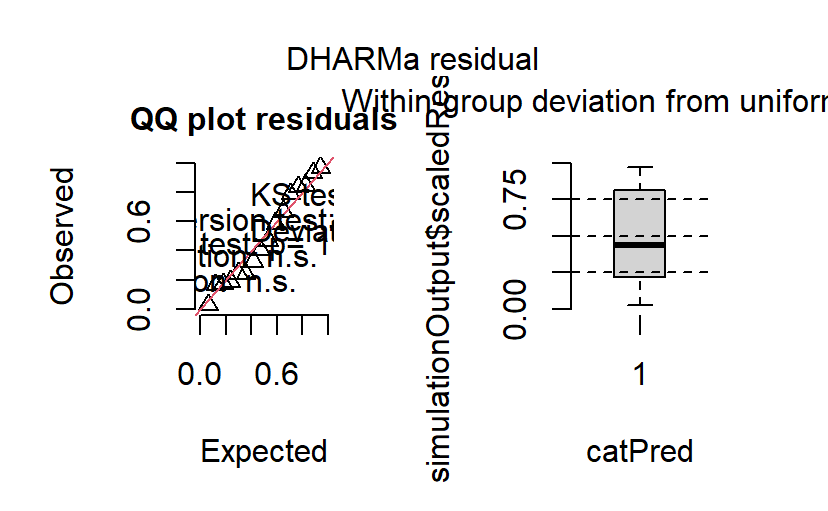

```r
plot(simulateResiduals(KT_bl.mod.null))
```

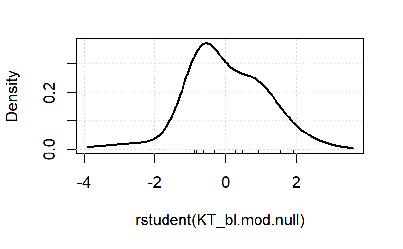

```r
densityPlot(rstudent(KT_bl.mod.null)) # check density estimate of the distribution of residuals
```

```r
outlierTest(KT_bl.mod.null)
```

```
No Studentized residuals with Bonferroni p < 0.05
Largest |rstudent|:
```

|  | rstudent | unadjusted p-value | Bonferroni p |
| --- | --- | --- | --- |
| 4 | -2.230868 | 0.02569 | 0.41104 |

[figure not shown]

```r
influenceIndexPlot(KT_bl.mod.null, vars = c("Cook"), id = list(n = 3))
```

```r
# model comparison techniques
anova(KT_bl.mod.full, KT_bl.mod.null, test = "F")
```

```
Analysis of Deviance Table

Model 1: SES_bl ~ trmt + pland + enn
Model 2: SES_bl ~ 1
  Resid. Df Resid. Dev Df Deviance      F Pr(>F)
1        12     16.995
2        15     17.974 -3 -0.97918 0.2305 0.8734
```

```r
AICctab(KT_bl.mod.full, KT_bl.mod.null)
```

```
               dAICc df
KT_bl.mod.null  0.0  2
KT_bl.mod.full 10.2  5
```

###VL BL Models

```r
VL_bl.mod.full <- glm(SES_bl ~ trmt + pland + enn, family = gaussian, data = VL_comps)
summary(VL_bl.mod.full)
```

```
Call:
glm(formula = SES_bl ~ trmt + pland + enn, family = gaussian,
    data = VL_comps)

Deviance Residuals:
    Min       1Q   Median       3Q      Max
-1.2646  -0.8783  -0.2414   0.9745   1.5188

Coefficients:
            Estimate Std. Error t value Pr(>|t|)
(Intercept) -4.42157    4.88188  -0.906    0.382
trmtT1       0.67815    0.58255   1.164    0.265
pland        0.07443    0.06094   1.221    0.244
enn          0.17837    0.44934   0.397    0.698

(Dispersion parameter for gaussian family taken to be 1.140808)

    Null deviance: 17.713  on 16  degrees of freedom
Residual deviance: 14.831  on 13  degrees of freedom
AIC: 55.923

Number of Fisher Scoring iterations: 2
```

```r
step(VL_bl.mod.full)
```

```
Start:  AIC=55.92
SES_bl ~ trmt + pland + enn

        Df Deviance    AIC
- enn    1   15.010 54.128
- trmt   1   16.377 55.609
- pland  1   16.532 55.770
<none>       14.831 55.923

Step:  AIC=54.13
SES_bl ~ trmt + pland

        Df Deviance    AIC
- trmt   1   16.829 54.072
<none>       15.010 54.128
- pland  1   17.026 54.270

Step:  AIC=54.07
SES_bl ~ pland

        Df Deviance    AIC
- pland  1   17.713 52.942
<none>       16.829 54.072

Step:  AIC=52.94
SES_bl ~ 1


Call:  glm(formula = SES_bl ~ 1, family = gaussian, data = VL_comps)

Coefficients:
(Intercept)
     0.1456

Degrees of Freedom: 16 Total (i.e. Null);  16 Residual
Null Deviance:      17.71
Residual Deviance: 17.71    AIC: 52.94
```

```r
VL_bl.mod.null <- glm(SES_bl ~ 1, family = gaussian, data = VL_comps)
summary(VL_bl.mod.null)
```

```
Call:
glm(formula = SES_bl ~ 1, family = gaussian, data = VL_comps)

Deviance Residuals:
    Min       1Q   Median       3Q      Max
-1.9547  -0.5864  -0.3374   0.8195   2.3253

Coefficients:
            Estimate Std. Error t value Pr(>|t|)
(Intercept)   0.1456     0.2552   0.571    0.576

(Dispersion parameter for gaussian family taken to be 1.107052)

    Null deviance: 17.713  on 16  degrees of freedom
Residual deviance: 17.713  on 16  degrees of freedom
AIC: 52.942

Number of Fisher Scoring iterations: 2
```

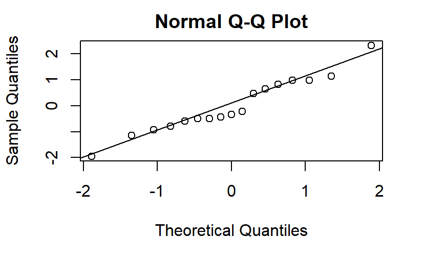

```r
qqnorm(resid(VL_bl.mod.null))
qqline(resid(VL_bl.mod.null))
```

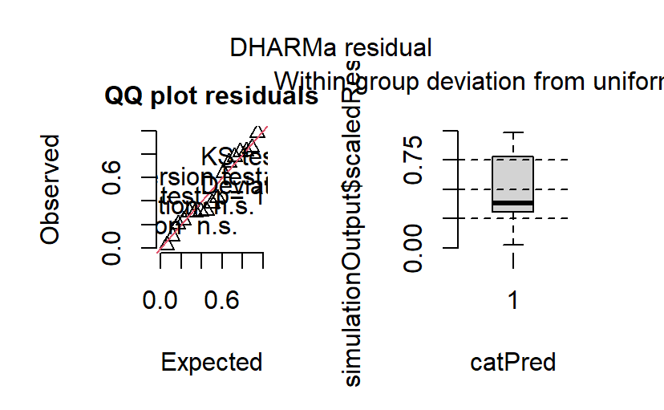

```r
plot(simulateResiduals(VL_bl.mod.null))
```

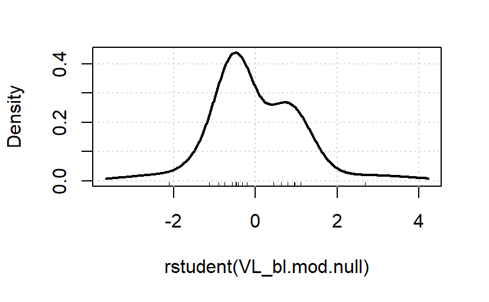

```r
densityPlot(rstudent(VL_bl.mod.null)) # check density estimate of the distribution of residuals
```

```r
outlierTest(VL_bl.mod.null)
```

```
No Studentized residuals with Bonferroni p < 0.05
Largest |rstudent|:
```

|  | rstudent | unadjusted p-value | Bonferroni p |
| --- | --- | --- | --- |
| 3 | 2.683396 | 0.0072879 | 0.12389 |

[figure not shown]

```r
influenceIndexPlot(VL_bl.mod.null, vars = c("Cook"), id = list(n = 3))
```

```r
# model comparison techniques
anova(VL_bl.mod.full, VL_bl.mod.null, test = "F")
```

```
Analysis of Deviance Table

Model 1: SES_bl ~ trmt + pland + enn
Model 2: SES_bl ~ 1
  Resid. Df Resid. Dev Df Deviance      F Pr(>F)
1        13     14.831
2        16     17.713 -3  -2.8823 0.8422 0.4948
```

```r
AICctab(VL_bl.mod.full, VL_bl.mod.null)
```

```
               dAICc df
VL_bl.mod.null 0.0   2
VL_bl.mod.full 7.6   5
```

# lecty

##lec_0- Kleptoparasitic

Normality Tests

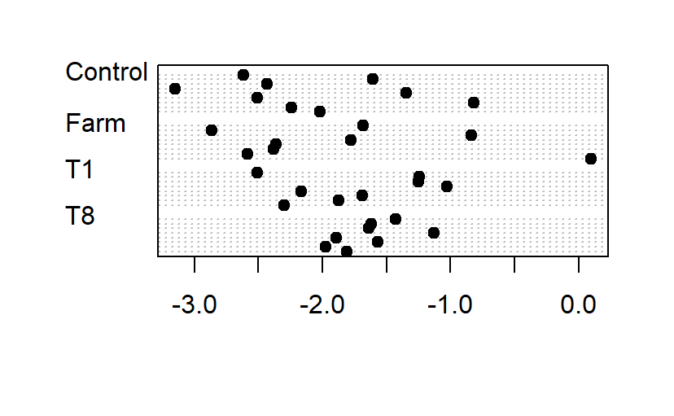

```r
dotchart(SES$SES_lec_0, group = SES$trmt, pch = 19)
```

```r
with(FS_comps, bartlett.test(SES_lec_0 ~ trmt))
```

```
    Bartlett test of homogeneity of variances

data:  SES_lec_0 by trmt
Bartlett's K-squared = 0.74599, df = 1,
p-value = 0.3877
```

```r
with(KT_comps, bartlett.test(SES_lec_0 ~ trmt))
```

```
    Bartlett test of homogeneity of variances

data:  SES_lec_0 by trmt
Bartlett's K-squared = 3.0189, df = 1,
p-value = 0.0823
```

```r
with(VL_comps, bartlett.test(SES_lec_0 ~ trmt))
```

```
    Bartlett test of homogeneity of variances

data:  SES_lec_0 by trmt
Bartlett's K-squared = 0.51024, df = 1,
p-value = 0.475
```

```r
with(FS_comps, ad.test(SES_lec_0))
```

```
    Anderson-Darling normality test

data:  SES_lec_0
A = 0.48176, p-value = 0.2009
```

```r
with(KT_comps, ad.test(SES_lec_0))
```

```
    Anderson-Darling normality test

data:  SES_lec_0
A = 0.15001, p-value = 0.9517
```

```r
with(VL_comps, ad.test(SES_lec_0))
```

```
    Anderson-Darling normality test

data:  SES_lec_0
A = 0.24911, p-value = 0.7046
```

####Frances

```r
FS_lec_0.mod.full <- glm(SES_lec_0 ~ trmt + pland + enn, family = gaussian, data = FS_comps)
summary(FS_lec_0.mod.full)
```

```
Call:
glm(formula = SES_lec_0 ~ trmt + pland + enn, family = gaussian,
    data = FS_comps)

Deviance Residuals:
    Min       1Q   Median       3Q      Max
-1.0190  -0.5656  -0.1681   0.4488   1.9056

Coefficients:
             Estimate Std. Error t value
(Intercept) -2.074622   4.244303  -0.489
trmtFarm     0.382107   0.628391   0.608
pland        0.007368   0.060095   0.123
enn         -0.061536   0.444528  -0.138
            Pr(>|t|)
(Intercept)    0.633
trmtFarm       0.554
pland          0.904
enn            0.892

(Dispersion parameter for gaussian family taken to be 0.8491786)

    Null deviance: 11.423  on 16  degrees of freedom
Residual deviance: 11.039  on 13  degrees of freedom
AIC: 50.904

Number of Fisher Scoring iterations: 2
```

```r
step(FS_lec_0.mod.full)
```

```
Start:  AIC=50.9
SES_lec_0 ~ trmt + pland + enn

        Df Deviance    AIC
- pland  1   11.052 48.924
- enn    1   11.056 48.929
- trmt   1   11.353 49.381
<none>       11.039 50.904

Step:  AIC=48.92
SES_lec_0 ~ trmt + enn

       Df Deviance    AIC
- enn   1   11.082 46.970
- trmt  1   11.374 47.413
<none>      11.052 48.924

Step:  AIC=46.97
SES_lec_0 ~ trmt

       Df Deviance    AIC
- trmt  1   11.423 45.485
<none>      11.082 46.970

Step:  AIC=45.48
SES_lec_0 ~ 1


Call:  glm(formula = SES_lec_0 ~ 1, family = gaussian, data = FS_comps)

Coefficients:
(Intercept)
     -1.948

Degrees of Freedom: 16 Total (i.e. Null);  16 Residual
Null Deviance:      11.42
Residual Deviance: 11.42    AIC: 45.48
```

```r
FS_lec_0.mod.null <- glm(SES_lec_0 ~ 1, family = gaussian, data = FS_comps)
summary(FS_lec_0.mod.null)
qqnorm(resid(FS_lec_0.mod.null))
qqline(resid(FS_lec_0.mod.null))
plot(simulateResiduals(FS_lec_0.mod.null))
densityPlot(rstudent(FS_lec_0.mod.null)) # check density estimate of the distribution of residuals
outlierTest(FS_lec_0.mod.null)
influenceIndexPlot(FS_lec_0.mod.null, vars = c("Cook"), id = list(n = 3))
#It looks like the first point might be a significant outlier
FS_lec_0.mod.null2 <- update(FS_lec_0.mod.null, subset = -c(1))
summary(FS_lec_0.mod.null2)
compareCoefs(FS_lec_0.mod.null, FS_lec_0.mod.null2) # compares estimated coefficients and their standard errors
#For some reason I got an error when I tried the above code
#And I can't test the below comparisons, because they don't run with it having 1 fewer data point

# model comparison techniques
anova(FS_lec_0.mod.full, FS_lec_0.mod.null,  test = "F")
AICctab(FS_lec_0.mod.full, FS_lec_0.mod.null)
```

####Katies

```r
KT_lec_0.mod.full <- glm(SES_lec_0 ~ trmt + pland + enn, family = gaussian, data = KT_comps)
summary(KT_lec_0.mod.full)
```

```
Call:
glm(formula = SES_lec_0 ~ trmt + pland + enn, family = gaussian,
    data = KT_comps)

Deviance Residuals:
     Min        1Q    Median        3Q
-0.73426  -0.21181  -0.05984   0.23053
     Max
 0.60020

Coefficients:
              Estimate Std. Error t value
(Intercept) -0.6537601  1.7390053  -0.376
trmtT8       0.1134978  0.2139814   0.530
pland       -0.0008308  0.0209087  -0.040
enn         -0.1684821  0.1616341  -1.042
            Pr(>|t|)
(Intercept)    0.714
trmtT8         0.606
pland          0.969
enn            0.318

(Dispersion parameter for gaussian family taken to be 0.1829387)

    Null deviance: 2.6637  on 15  degrees of freedom
Residual deviance: 2.1953  on 12  degrees of freedom
AIC: 23.625

Number of Fisher Scoring iterations: 2
```

```r
step(KT_lec_0.mod.full)
```

```
Start:  AIC=23.63
SES_lec_0 ~ trmt + pland + enn

        Df Deviance    AIC
- pland  1   2.1955 21.628
- trmt   1   2.2467 21.996
- enn    1   2.3940 23.012
<none>       2.1953 23.625

Step:  AIC=21.63
SES_lec_0 ~ trmt + enn

       Df Deviance    AIC
- trmt  1   2.2470 19.998
<none>      2.1955 21.628
- enn   1   2.6019 22.344

Step:  AIC=20
SES_lec_0 ~ enn

       Df Deviance    AIC
<none>      2.2470 19.998
- enn   1   2.6637 20.720

Call:  glm(formula = SES_lec_0 ~ enn, family = gaussian, data = KT_comps)

Coefficients:
(Intercept)          enn
    -0.6475      -0.1658

Degrees of Freedom: 15 Total (i.e. Null);  14 Residual
Null Deviance:      2.664
Residual Deviance: 2.247    AIC: 20
```

```r
KT_lec_0.mod.red <- glm(SES_lec_0 ~ enn, family = gaussian, data = KT_comps)
summary(KT_lec_0.mod.red)
```

```
Call:
glm(formula = SES_lec_0 ~ enn, family = gaussian, data = KT_comps)

Deviance Residuals:
     Min        1Q    Median        3Q
-0.79668  -0.26401  -0.00484   0.27483
     Max
 0.54033

Coefficients:
            Estimate Std. Error t value Pr(>|t|)
(Intercept)  -0.6475     0.6564  -0.986    0.341
enn          -0.1658     0.1029  -1.611    0.129

(Dispersion parameter for gaussian family taken to be 0.1605005)

    Null deviance: 2.6637  on 15  degrees of freedom
Residual deviance: 2.2470  on 14  degrees of freedom
AIC: 19.998

Number of Fisher Scoring iterations: 2
```

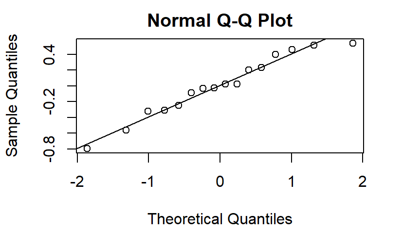

```r
qqnorm(resid(KT_lec_0.mod.red))
qqline(resid(KT_lec_0.mod.red))
```

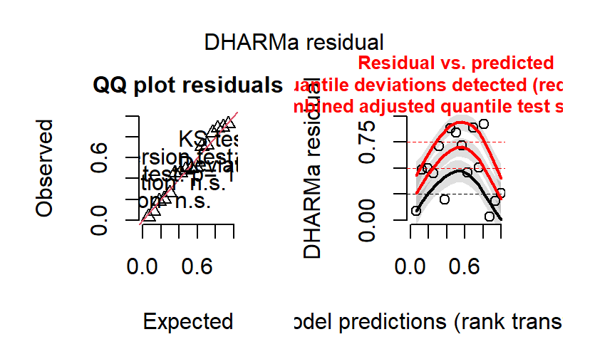

```r
plot(simulateResiduals(KT_lec_0.mod.red))
```

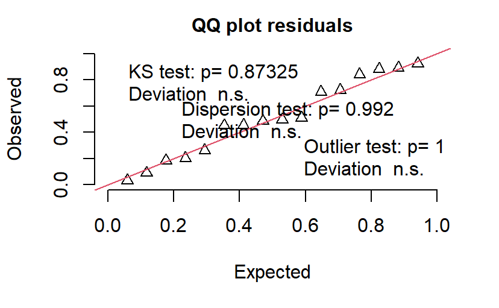

```r
#I am adding the below code to look at the graphs individually. the second one has red lines
plotQQunif(KT_lec_0.mod.red)
```

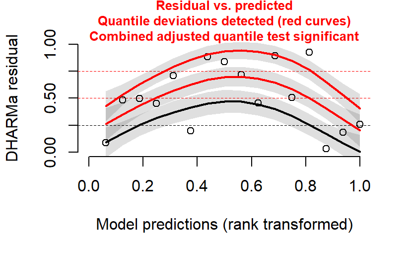

```r
plotResiduals(KT_lec_0.mod.red)
```

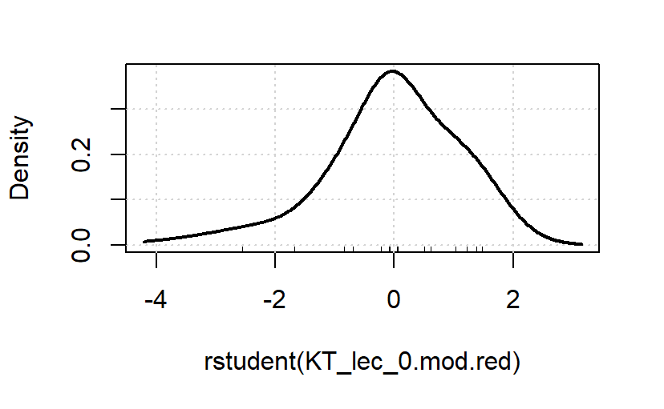

```r
#It says that there are significant quantile deviations

densityPlot(rstudent(KT_lec_0.mod.red)) # check density estimate of the distribution of residuals
```

```r
outlierTest(KT_lec_0.mod.red)
```

```
No Studentized residuals with Bonferroni p < 0.05
Largest |rstudent|:
```

|  | rstudent | unadjusted p-value | Bonferroni p |
| --- | --- | --- | --- |
| 3 | -2.547097 | 0.010862 | 0.1738 |

[figure not shown]

```r
influenceIndexPlot(KT_lec_0.mod.red, vars = c("Cook"), id = list(n = 3))
```

```r
KT_lec_0.mod.null <- glm(SES_lec_0 ~ 1, family = gaussian, data = KT_comps)

# model comparison techniques
anova(KT_lec_0.mod.full, KT_lec_0.mod.red, KT_lec_0.mod.null,  test = "F")
```

```
Analysis of Deviance Table

Model 1: SES_lec_0 ~ trmt + pland + enn
Model 2: SES_lec_0 ~ enn
Model 3: SES_lec_0 ~ 1
  Resid. Df Resid. Dev Df Deviance      F Pr(>F)
1        12     2.1953
2        14     2.2470 -2 -0.05174 0.1414 0.8695
3        15     2.6637 -1 -0.41673 2.2780 0.1571
```

```r
AICctab(KT_lec_0.mod.full, KT_lec_0.mod.red, KT_lec_0.mod.null)
```

```
                  dAICc df
KT_lec_0.mod.null 0.0   2
KT_lec_0.mod.red  0.4   3
KT_lec_0.mod.full 8.0   5
```

####Vacant Lots

```r
VL_lec_0.mod.full <- glm(SES_lec_0 ~ trmt + pland + enn, family = gaussian, data = VL_comps)
summary(VL_lec_0.mod.full)
```

```
Call:
glm(formula = SES_lec_0 ~ trmt + pland + enn, family = gaussian,
    data = VL_comps)

Deviance Residuals:
     Min        1Q    Median        3Q
-0.94074  -0.46138   0.04371   0.38349
     Max
 1.17521

Coefficients:
             Estimate Std. Error t value
(Intercept) -3.780969   2.943333  -1.285
trmtT1       0.531151   0.351224   1.512
pland        0.037070   0.036740   1.009
enn          0.002336   0.270910   0.009
            Pr(>|t|)
(Intercept)    0.221
trmtT1         0.154
pland          0.331
enn            0.993

(Dispersion parameter for gaussian family taken to be 0.4146831)

    Null deviance: 6.6745  on 16  degrees of freedom
Residual deviance: 5.3909  on 13  degrees of freedom
AIC: 38.719

Number of Fisher Scoring iterations: 2
```

```r
step(VL_lec_0.mod.full)
```

```
Start:  AIC=38.72
SES_lec_0 ~ trmt + pland + enn

        Df Deviance    AIC
- enn    1   5.3909 36.719
- pland  1   5.8131 38.001
<none>       5.3909 38.719
- trmt   1   6.3393 39.474

Step:  AIC=36.72
SES_lec_0 ~ trmt + pland

        Df Deviance    AIC
<none>       5.3909 36.719
- pland  1   6.2229 37.159
- trmt   1   6.3770 37.575

Call:  glm(formula = SES_lec_0 ~ trmt + pland, family = gaussian, data = VL_comps)

Coefficients:
(Intercept)       trmtT1        pland
   -3.75781      0.53173      0.03685

Degrees of Freedom: 16 Total (i.e. Null);  14 Residual
Null Deviance:      6.675
Residual Deviance: 5.391    AIC: 36.72
```

```r
VL_lec_0.mod.red <- glm(SES_lec_0 ~ trmt+pland, family = gaussian, data = VL_comps)
summary(VL_lec_0.mod.red)
```

```
Call:
glm(formula = SES_lec_0 ~ trmt + pland, family = gaussian, data = VL_comps)

Deviance Residuals:
     Min        1Q    Median        3Q
-0.94111  -0.45908   0.04022   0.38322
     Max
 1.17681

Coefficients:
            Estimate Std. Error t value Pr(>|t|)
(Intercept) -3.75781    1.15901  -3.242   0.0059
trmtT1       0.53173    0.33227   1.600   0.1318
pland        0.03685    0.02507   1.470   0.1637

(Intercept) **
trmtT1
pland
---
Signif. codes:
0 ‘***’ 0.001 ‘**’ 0.01 ‘*’ 0.05 ‘.’ 0.1 ‘ ’ 1

(Dispersion parameter for gaussian family taken to be 0.3850651)

    Null deviance: 6.6745  on 16  degrees of freedom
Residual deviance: 5.3909  on 14  degrees of freedom
AIC: 36.719

Number of Fisher Scoring iterations: 2
```